# Assingment2

```python
import pandas as pd
import numpy as np
import matplotlib.pyplot as plt
%matplotlib inline
from sklearn.metrics import accuracy_score, confusion_matrix
pd.set_option('use_inf_as_na', True)
from collections import Counter
```

```python
!pip install optuna
import optuna
from optuna.trial import Trial
import warnings
warnings.filterwarnings("ignore")
```

```
WARNING: There was an error checking the latest version of pip.
```

```python
from functools import partial

import pandas as pd
import numpy as np
import matplotlib.pyplot as plt
%matplotlib inline

from sklearn.tree import DecisionTreeClassifier
from sklearn.ensemble import RandomForestClassifier
import sklearn
pd.set_option('use_inf_as_na', True)
from collections import Counter
from sklearn.preprocessing import MinMaxScaler,StandardScaler
from sklearn.ensemble import BaggingClassifier
```

```python
!pip install numba
import shap
```

```
WARNING: There was an error checking the latest version of pip.
```

```python
raw_data = pd.read_pickle('/Users/yiningqu/Desktop/dataset.pkl')
raw_data = raw_data.drop([x  for x in raw_data.columns if 'fqtr' in x],axis=1)
# keep only firms with market capitalization larger than 1 billion
data = raw_data[raw_data['market_cap'] > 1000.0]

#clean dataset
data = data.copy()
data.replace([np.inf,-np.inf],np.nan,inplace=True)
data = data.fillna(method='ffill')
data = data.fillna(0)
data.head()
```

| date | ticker | actq | apq | atq | ceqq | cheq | cogsq | csh12q | cshfdq | cshiq | cshopq | ... | sector_code_815.0 | sector_code_817.0 | sector_code_822.0 | sector_code_823.0 | sector_code_825.0 | sector_code_830.0 | sector_code_835.0 | sector_code_840.0 | sector_code_845.0 | sector_code_850.0 |
| --- | --- | --- | --- | --- | --- | --- | --- | --- | --- | --- | --- | --- | --- | --- | --- | --- | --- | --- | --- | --- | --- | --- |
| 2000-02-09 | CSCO | 7722.000 | 482.000 | 21391.000 | 16523.000 | 3968.000 | 1422.000 | 3374.1250 | 3648.000 | 3445.000 | 0.0 | ... | 0 | 0 | 0 | 0 | 0 | 0 | 0 | 0 | 0 | 0 |
|  | ROP | 172.725 | 19.662 | 474.649 | 239.432 | 3.198 | 47.634 | 30.2688 | 31.217 | 3445.000 | 0.0 | ... | 0 | 0 | 0 | 0 | 0 | 0 | 0 | 0 | 0 | 0 |
| 2000-02-10 | CMOS | 240.767 | 27.044 | 376.536 | 209.411 | 68.625 | 43.023 | 21.4360 | 23.753 | 3445.000 | 0.0 | ... | 0 | 0 | 0 | 0 | 0 | 0 | 0 | 0 | 0 | 0 |
| 2000-02-11 | DELL | 7681.000 | 3538.000 | 11471.000 | 5308.000 | 4132.000 | 5452.000 | 2536.0000 | 2731.000 | 2575.000 | 0.0 | ... | 0 | 0 | 0 | 0 | 0 | 0 | 0 | 0 | 0 | 0 |
| 2000-02-15 | VAL | 507.082 | 139.497 | 1094.080 | 402.382 | 27.605 | 221.366 | 43.1858 | 43.687 | 53.321 | 0.0 | ... | 0 | 0 | 0 | 0 | 0 | 0 | 0 | 0 | 0 | 0 |

5 rows × 727 columns

# Q1-a

Insert a column in the data set where the entries are 1 if the stock outperforms SPY by more than 5% in the earnings period and -1 if it underperforms by -10% and 0 if the performance is between these values.

```python
def f(x):
    if x > .05:
        return 1
    elif x < -.1:
        return -1
    else:
        return 0
```

```python
data = data.copy()
data['rel_performance'] = data['pred_rel_return'].apply(f)
```

```python
data[['pred_rel_return','rel_performance']]
```

| date | ticker | pred_rel_return | rel_performance |
| --- | --- | --- | --- |
| 2000-02-09 | CSCO | -0.025923 | 0 |
|  | ROP | 0.066175 | 1 |
| 2000-02-10 | CMOS | 0.241345 | 1 |
| 2000-02-11 | DELL | 0.306035 | 1 |
| 2000-02-15 | VAL | 0.043852 | 0 |
| ... | ... | ... | ... |
| 2018-12-21 | NKE | -0.100100 | -1 |
|  | SAFM | -0.100100 | -1 |
|  | SCHL | -0.100100 | -1 |
|  | WBA | -0.100100 | -1 |
| 2018-12-24 | KMX | -0.100100 | -1 |

111468 rows × 2 columns

```python
data.reset_index(inplace=True)
data.set_index('date',inplace=True)
data.sort_index()
```

| date | ticker | actq | apq | atq | ceqq | cheq | cogsq | csh12q | cshfdq | cshiq | ... | sector_code_817.0 | sector_code_822.0 | sector_code_823.0 | sector_code_825.0 | sector_code_830.0 | sector_code_835.0 | sector_code_840.0 | sector_code_845.0 | sector_code_850.0 | rel_performance |
| --- | --- | --- | --- | --- | --- | --- | --- | --- | --- | --- | --- | --- | --- | --- | --- | --- | --- | --- | --- | --- | --- |
| 2000-02-09 | CSCO | 7722.000 | 482.000 | 21391.000 | 16523.000 | 3968.000 | 1422.000 | 3374.1250 | 3648.000 | 3445.000 | ... | 0 | 0 | 0 | 0 | 0 | 0 | 0 | 0 | 0 | 0 |
| 2000-02-09 | ROP | 172.725 | 19.662 | 474.649 | 239.432 | 3.198 | 47.634 | 30.2688 | 31.217 | 3445.000 | ... | 0 | 0 | 0 | 0 | 0 | 0 | 0 | 0 | 0 | 1 |
| 2000-02-10 | CMOS | 240.767 | 27.044 | 376.536 | 209.411 | 68.625 | 43.023 | 21.4360 | 23.753 | 3445.000 | ... | 0 | 0 | 0 | 0 | 0 | 0 | 0 | 0 | 0 | 1 |
| 2000-02-11 | DELL | 7681.000 | 3538.000 | 11471.000 | 5308.000 | 4132.000 | 5452.000 | 2536.0000 | 2731.000 | 2575.000 | ... | 0 | 0 | 0 | 0 | 0 | 0 | 0 | 0 | 0 | 1 |
| 2000-02-15 | VAL | 507.082 | 139.497 | 1094.080 | 402.382 | 27.605 | 221.366 | 43.1858 | 43.687 | 53.321 | ... | 0 | 0 | 0 | 0 | 0 | 0 | 0 | 0 | 0 | 0 |
| ... | ... | ... | ... | ... | ... | ... | ... | ... | ... | ... | ... | ... | ... | ... | ... | ... | ... | ... | ... | ... | ... |
| 2018-12-21 | NKE | 15566.000 | 2574.000 | 22677.000 | 8729.000 | 4041.000 | 5098.000 | 1601.1500 | 1620.700 | 1577.000 | ... | 0 | 0 | 0 | 0 | 0 | 0 | 0 | 0 | 0 | -1 |
| 2018-12-21 | SAFM | 566.489 | 128.936 | 1659.440 | 1387.893 | 121.193 | 758.313 | 22.4290 | 22.191 | 22.100 | ... | 0 | 0 | 0 | 0 | 0 | 0 | 0 | 0 | 0 | -1 |
| 2018-12-21 | SCHL | 1172.300 | 250.300 | 2081.900 | 1284.600 | 358.100 | 262.400 | 35.0420 | 35.863 | 22.100 | ... | 0 | 0 | 0 | 0 | 0 | 0 | 0 | 0 | 0 | -1 |
| 2018-12-21 | WBA | 20083.000 | 14660.000 | 69941.000 | 25609.000 | 1183.000 | 25651.000 | 976.4750 | 951.400 | 1172.514 | ... | 0 | 0 | 0 | 0 | 0 | 0 | 0 | 0 | 0 | -1 |
| 2018-12-24 | KMX | 3057.419 | 558.324 | 18396.812 | 3435.113 | 461.662 | 3819.336 | 177.2235 | 175.321 | 171.785 | ... | 0 | 0 | 0 | 0 | 0 | 0 | 0 | 0 | 0 | -1 |

111468 rows × 729 columns

# Q1-b

Create both a DecisionTree classifier, a BaggingClassifier and a RandomForestClassifier. Use Optuna to find optimal hyperparameters.

```python
df_train = data.loc['2007-01-01':'2010-01-01']
df_valid = data.loc['2010-04-01':'2010-07-01']
df_test = data.loc['2010-01-01':'2019-01-01']
```

```python
train = df_train.reset_index().drop(['ticker','date',
                                   'next_period_return',
                                   'spy_next_period_return',
                                   'rel_performance','pred_rel_return',
                                  'return', 'cum_ret', 'spy_cum_ret'],axis=1)

valid = df_valid.reset_index().drop(['ticker','date',
                                    'next_period_return',
                                   'spy_next_period_return',
                                   'rel_performance','pred_rel_return',
                                  'return', 'cum_ret', 'spy_cum_ret'],axis=1)

test = df_test.reset_index().drop(['ticker','date',
                                   'next_period_return',
                                   'spy_next_period_return',
                                   'rel_performance','pred_rel_return',
                                  'return', 'cum_ret', 'spy_cum_ret'],axis=1)
```

```python
train_stock_returns = df_train['next_period_return']
valid_stock_returns = df_valid['next_period_return']
test_stock_returns = df_test['next_period_return']

scaler = StandardScaler()
float_vars = [x for x in train.columns if data[x].dtype == 'float64']

train = train.copy()
valid = valid.copy()
test = test.copy()
```

```python
train[float_vars] = scaler.fit_transform(train[float_vars])
valid[float_vars] = scaler.transform(valid[float_vars])
test[float_vars] = scaler.transform(test[float_vars])
```

```python
y_train = df_train['rel_performance']
y_valid = df_valid['rel_performance']
y_test = df_test['rel_performance']

y_train = y_train.values
y_valid = y_valid.values
y_test = y_test.values
```

```python
# Simple Decision Tree Classifier Optimal Hyperparameters

def objective(trial:Trial,train=None,labels=None,val=None,val_labels=None,val_rets=None):
    t_min_samples_leaf = trial.suggest_int('min_samples_leaf',100,1200,step=100)
    t_max_depth = trial.suggest_int('max_depth',5,25,step=5)

    simple_t_clf = DecisionTreeClassifier(min_samples_leaf = t_min_samples_leaf,max_depth=t_max_depth,random_state=123)
    simple_t_clf.fit(train,labels)

    preds = simple_t_clf.predict(val)
    profit = (preds * val_rets).sum()

    return profit
```

```python
 study = optuna.create_study(direction="maximize")
```

```
[I 2024-02-04 23:05:52,606] A new study created in memory with name: no-name-e5ce91ac-ca3e-4e7d-b12d-46984adc1aea
```

```python
%%time
study.optimize(partial(objective,train=train,labels=y_train,val=valid,val_labels=y_valid,val_rets=valid_stock_returns.values), n_trials=100,n_jobs=-1)
```

```
[I 2024-02-04 23:05:56,114] Trial 5 finished with value: -27.28105700000001 and parameters: {'min_samples_leaf': 1000, 'max_depth': 25}. Best is trial 5 with value: -27.28105700000001.
[I 2024-02-04 23:05:56,510] Trial 1 finished with value: -22.085359000000015 and parameters: {'min_samples_leaf': 700, 'max_depth': 10}. Best is trial 1 with value: -22.085359000000015.
[I 2024-02-04 23:05:56,729] Trial 4 finished with value: -22.085359000000015 and parameters: {'min_samples_leaf': 700, 'max_depth': 25}. Best is trial 1 with value: -22.085359000000015.
[I 2024-02-04 23:05:56,780] Trial 6 finished with value: -22.085359000000015 and parameters: {'min_samples_leaf': 700, 'max_depth': 10}. Best is trial 1 with value: -22.085359000000015.
[I 2024-02-04 23:05:57,172] Trial 3 finished with value: -27.884301000000022 and parameters: {'min_samples_leaf': 500, 'max_depth': 25}. Best is trial 1 with value: -22.085359000000015.
[I 2024-02-04 23:05:57,184] Trial 2 finished with value: -27.884301000000022 and parameters: {'min_samples_leaf': 500, 'max_depth': 25}. Best is trial 1 with value: -22.085359000000015.
[I 2024-02-04 23:05:57,786] Trial 7 finished with value: -22.97220800000002 and parameters: {'min_samples_leaf': 400, 'max_depth': 10}. Best is trial 1 with value: -22.085359000000015.
[I 2024-02-04 23:05:58,828] Trial 0 finished with value: -30.59973300000003 and parameters: {'min_samples_leaf': 200, 'max_depth': 15}. Best is trial 1 with value: -22.085359000000015.
[I 2024-02-04 23:05:59,919] Trial 8 finished with value: -27.28105700000001 and parameters: {'min_samples_leaf': 1000, 'max_depth': 15}. Best is trial 1 with value: -22.085359000000015.
[I 2024-02-04 23:06:00,524] Trial 9 finished with value: -27.28105700000001 and parameters: {'min_samples_leaf': 1000, 'max_depth': 10}. Best is trial 1 with value: -22.085359000000015.
[I 2024-02-04 23:06:01,334] Trial 10 finished with value: -28.382911000000007 and parameters: {'min_samples_leaf': 900, 'max_depth': 25}. Best is trial 1 with value: -22.085359000000015.
[I 2024-02-04 23:06:01,516] Trial 12 finished with value: -36.20374300000003 and parameters: {'min_samples_leaf': 1200, 'max_depth': 10}. Best is trial 1 with value: -22.085359000000015.
[I 2024-02-04 23:06:02,214] Trial 11 finished with value: -34.95954000000004 and parameters: {'min_samples_leaf': 200, 'max_depth': 5}. Best is trial 1 with value: -22.085359000000015.
[I 2024-02-04 23:06:04,120] Trial 15 finished with value: -22.085359000000015 and parameters: {'min_samples_leaf': 700, 'max_depth': 15}. Best is trial 1 with value: -22.085359000000015.
[I 2024-02-04 23:06:04,906] Trial 17 finished with value: -36.20374300000003 and parameters: {'min_samples_leaf': 1200, 'max_depth': 5}. Best is trial 1 with value: -22.085359000000015.
[I 2024-02-04 23:06:06,197] Trial 16 finished with value: -27.884301000000022 and parameters: {'min_samples_leaf': 500, 'max_depth': 20}. Best is trial 1 with value: -22.085359000000015.
[I 2024-02-04 23:06:06,374] Trial 18 finished with value: -26.883373000000013 and parameters: {'min_samples_leaf': 700, 'max_depth': 5}. Best is trial 1 with value: -22.085359000000015.
[I 2024-02-04 23:06:06,574] Trial 19 finished with value: -26.883373000000013 and parameters: {'min_samples_leaf': 700, 'max_depth': 5}. Best is trial 1 with value: -22.085359000000015.
[I 2024-02-04 23:06:06,748] Trial 13 finished with value: -22.796233000000015 and parameters: {'min_samples_leaf': 100, 'max_depth': 25}. Best is trial 1 with value: -22.085359000000015.
[I 2024-02-04 23:06:07,095] Trial 14 finished with value: -22.612129000000014 and parameters: {'min_samples_leaf': 100, 'max_depth': 15}. Best is trial 1 with value: -22.085359000000015.
[I 2024-02-04 23:06:07,612] Trial 20 finished with value: -22.085359000000015 and parameters: {'min_samples_leaf': 700, 'max_depth': 20}. Best is trial 1 with value: -22.085359000000015.
[I 2024-02-04 23:06:09,168] Trial 21 finished with value: -27.609009 and parameters: {'min_samples_leaf': 800, 'max_depth': 20}. Best is trial 1 with value: -22.085359000000015.
[I 2024-02-04 23:06:09,657] Trial 22 finished with value: -27.609009 and parameters: {'min_samples_leaf': 800, 'max_depth': 20}. Best is trial 1 with value: -22.085359000000015.
[I 2024-02-04 23:06:10,876] Trial 23 finished with value: -27.609009 and parameters: {'min_samples_leaf': 800, 'max_depth': 20}. Best is trial 1 with value: -22.085359000000015.
[I 2024-02-04 23:06:11,060] Trial 25 finished with value: -28.382911000000007 and parameters: {'min_samples_leaf': 900, 'max_depth': 20}. Best is trial 1 with value: -22.085359000000015.
[I 2024-02-04 23:06:11,209] Trial 24 finished with value: -27.609009 and parameters: {'min_samples_leaf': 800, 'max_depth': 20}. Best is trial 1 with value: -22.085359000000015.
```

[output cut: 74 more lines]

```
CPU times: user 3min 55s, sys: 5.48 s, total: 4min 1s
Wall time: 1min
```

```python
study.best_params
```

```
{'min_samples_leaf': 700, 'max_depth': 10}
```

```python
simple_t_clf = DecisionTreeClassifier(**study.best_params,random_state=123)
simple_t_clf.fit(train,y_train)
```

```
DecisionTreeClassifier(max_depth=10, min_samples_leaf=700, random_state=123)
```

```python
preds_valid_simple_t_clf = simple_t_clf.predict(valid)
preds_valid_simple_t_clf
```

```
array([0, 0, 0, ..., 1, 1, 1])
```

```python
def objective_2(trial:Trial,train=None,labels=None,val=None,val_labels=None,val_rets=None):

    t_min_samples_leaf = trial.suggest_int('min_samples_leaf',100,1200,step=100)
    t_max_depth = trial.suggest_int('max_depth',5,25,step=5)
    t_n_estimators = trial.suggest_int('n_estimators',5,50,step=5)


    t_clf = DecisionTreeClassifier(min_samples_leaf = t_min_samples_leaf,max_depth=t_max_depth,random_state=123)
    bg_clf = BaggingClassifier(t_clf,n_estimators=t_n_estimators,random_state=123,n_jobs=1)
    bg_clf.fit(train,labels)

    preds = bg_clf.predict(val)
    profit = (preds * val_rets).sum()

    return profit
```

```python
study2 = optuna.create_study(direction="maximize")
```

```
[I 2024-02-04 23:06:55,446] A new study created in memory with name: no-name-981bb408-403c-4789-9500-40f8dd8395db
```

```python
%%time
study2.optimize(partial(objective_2,train=train,labels=y_train,val=valid,val_labels=y_valid,val_rets=valid_stock_returns.values), n_trials=200,n_jobs=-1)
```

```
[I 2024-02-04 23:07:11,092] Trial 7 finished with value: -30.75386900000002 and parameters: {'min_samples_leaf': 100, 'max_depth': 5, 'n_estimators': 5}. Best is trial 7 with value: -30.75386900000002.
[I 2024-02-04 23:07:16,917] Trial 2 finished with value: -37.15372000000002 and parameters: {'min_samples_leaf': 700, 'max_depth': 15, 'n_estimators': 10}. Best is trial 7 with value: -30.75386900000002.
[I 2024-02-04 23:07:21,379] Trial 3 finished with value: -39.50528100000002 and parameters: {'min_samples_leaf': 1000, 'max_depth': 25, 'n_estimators': 15}. Best is trial 7 with value: -30.75386900000002.
[I 2024-02-04 23:07:26,265] Trial 0 finished with value: -27.804215000000017 and parameters: {'min_samples_leaf': 300, 'max_depth': 15, 'n_estimators': 10}. Best is trial 0 with value: -27.804215000000017.
[I 2024-02-04 23:07:31,325] Trial 8 finished with value: -30.530770000000025 and parameters: {'min_samples_leaf': 100, 'max_depth': 25, 'n_estimators': 5}. Best is trial 0 with value: -27.804215000000017.
[I 2024-02-04 23:07:47,612] Trial 1 finished with value: -39.80449400000002 and parameters: {'min_samples_leaf': 900, 'max_depth': 20, 'n_estimators': 30}. Best is trial 0 with value: -27.804215000000017.
[I 2024-02-04 23:07:57,690] Trial 13 finished with value: -33.670638000000025 and parameters: {'min_samples_leaf': 600, 'max_depth': 20, 'n_estimators': 5}. Best is trial 0 with value: -27.804215000000017.
[I 2024-02-04 23:08:00,914] Trial 6 finished with value: -36.89985600000003 and parameters: {'min_samples_leaf': 500, 'max_depth': 5, 'n_estimators': 30}. Best is trial 0 with value: -27.804215000000017.
[I 2024-02-04 23:08:04,213] Trial 11 finished with value: -39.59726200000003 and parameters: {'min_samples_leaf': 1000, 'max_depth': 25, 'n_estimators': 25}. Best is trial 0 with value: -27.804215000000017.
[I 2024-02-04 23:08:11,544] Trial 4 finished with value: -39.52557800000003 and parameters: {'min_samples_leaf': 700, 'max_depth': 5, 'n_estimators': 40}. Best is trial 0 with value: -27.804215000000017.
[I 2024-02-04 23:08:15,965] Trial 10 finished with value: -37.22402200000003 and parameters: {'min_samples_leaf': 500, 'max_depth': 15, 'n_estimators': 25}. Best is trial 0 with value: -27.804215000000017.
[I 2024-02-04 23:08:22,993] Trial 15 finished with value: -39.50528100000002 and parameters: {'min_samples_leaf': 1000, 'max_depth': 5, 'n_estimators': 15}. Best is trial 0 with value: -27.804215000000017.
[I 2024-02-04 23:08:35,396] Trial 5 finished with value: -36.18217000000002 and parameters: {'min_samples_leaf': 400, 'max_depth': 5, 'n_estimators': 45}. Best is trial 0 with value: -27.804215000000017.
[I 2024-02-04 23:08:47,467] Trial 12 finished with value: -37.114120000000014 and parameters: {'min_samples_leaf': 100, 'max_depth': 5, 'n_estimators': 30}. Best is trial 0 with value: -27.804215000000017.
[I 2024-02-04 23:09:04,206] Trial 17 finished with value: -31.69234800000004 and parameters: {'min_samples_leaf': 300, 'max_depth': 15, 'n_estimators': 20}. Best is trial 0 with value: -27.804215000000017.
[I 2024-02-04 23:09:10,494] Trial 18 finished with value: -31.912234000000012 and parameters: {'min_samples_leaf': 100, 'max_depth': 10, 'n_estimators': 15}. Best is trial 0 with value: -27.804215000000017.
[I 2024-02-04 23:09:15,075] Trial 14 finished with value: -34.22151400000001 and parameters: {'min_samples_leaf': 300, 'max_depth': 5, 'n_estimators': 35}. Best is trial 0 with value: -27.804215000000017.
[I 2024-02-04 23:09:17,762] Trial 19 finished with value: -31.912234000000012 and parameters: {'min_samples_leaf': 100, 'max_depth': 10, 'n_estimators': 15}. Best is trial 0 with value: -27.804215000000017.
[I 2024-02-04 23:09:19,767] Trial 22 finished with value: -28.90891700000003 and parameters: {'min_samples_leaf': 200, 'max_depth': 10, 'n_estimators': 5}. Best is trial 0 with value: -27.804215000000017.
[I 2024-02-04 23:09:23,784] Trial 23 finished with value: -31.96304200000003 and parameters: {'min_samples_leaf': 300, 'max_depth': 20, 'n_estimators': 5}. Best is trial 0 with value: -27.804215000000017.
[I 2024-02-04 23:09:24,659] Trial 25 finished with value: -37.12865000000002 and parameters: {'min_samples_leaf': 1200, 'max_depth': 20, 'n_estimators': 5}. Best is trial 0 with value: -27.804215000000017.
[I 2024-02-04 23:09:27,340] Trial 21 finished with value: -29.914753000000022 and parameters: {'min_samples_leaf': 300, 'max_depth': 20, 'n_estimators': 15}. Best is trial 0 with value: -27.804215000000017.
[I 2024-02-04 23:09:28,029] Trial 24 finished with value: -31.96304200000003 and parameters: {'min_samples_leaf': 300, 'max_depth': 20, 'n_estimators': 5}. Best is trial 0 with value: -27.804215000000017.
[I 2024-02-04 23:09:29,581] Trial 9 finished with value: -35.012153000000026 and parameters: {'min_samples_leaf': 300, 'max_depth': 20, 'n_estimators': 50}. Best is trial 0 with value: -27.804215000000017.
[I 2024-02-04 23:09:30,480] Trial 20 finished with value: -31.912234000000012 and parameters: {'min_samples_leaf': 100, 'max_depth': 10, 'n_estimators': 15}. Best is trial 0 with value: -27.804215000000017.
[I 2024-02-04 23:09:39,422] Trial 16 finished with value: -39.323578000000026 and parameters: {'min_samples_leaf': 600, 'max_depth': 25, 'n_estimators': 50}. Best is trial 0 with value: -27.804215000000017.
```

[output cut: 174 more lines]

```
CPU times: user 1h 20min 9s, sys: 38.4 s, total: 1h 20min 48s
Wall time: 13min 27s
```

```python
study2.best_params
```

```
{'min_samples_leaf': 100, 'max_depth': 15, 'n_estimators': 10}
```

```python
t_clf = DecisionTreeClassifier(**{'min_samples_leaf': study2.best_params['min_samples_leaf'], 'max_depth': study2.best_params['max_depth']})
bg_clf = BaggingClassifier(t_clf,n_estimators=study2.best_params['n_estimators'],random_state=123)

bg_clf.fit(train,y_train)
```

```
BaggingClassifier(estimator=DecisionTreeClassifier(max_depth=15,
                                                   min_samples_leaf=100),
                  random_state=123)
```

```python
preds_valid_bg_clf = bg_clf.predict(valid)
preds_valid_bg_clf
```

```
array([1, 0, 1, ..., 1, 0, 1])
```

```python
# Random Forest Classifier Optimal Hyperparameters

def objective_3(trial:Trial,train=None,labels=None,val=None,val_labels=None,val_rets=None):

    rf_n_estimators = trial.suggest_int('n_estimators', 10,40,step=5)
    rf_max_features = trial.suggest_categorical('max_features',['sqrt','log2'])
    rf_min_samples_leaf = trial.suggest_int('min_samples_leaf',800,2400,step=800)
    rf_max_depth = trial.suggest_int('max_depth',4,15)

    rf_clf = RandomForestClassifier(n_estimators=rf_n_estimators,
                                    max_depth=rf_max_depth,
                                    min_samples_leaf=rf_min_samples_leaf,
                                    max_features=rf_max_features)
    rf_clf.fit(train,labels)
    accuracy = rf_clf.score(val,val_labels)

    return accuracy
```

```python
study3 = optuna.create_study(direction="maximize")
```

```
[I 2024-02-04 23:20:36,583] A new study created in memory with name: no-name-910538be-b9b6-4b6a-b3c6-3121ed309345
```

```python
%%time
study3.optimize(partial(objective_3,train=train,labels=y_train,val=valid,val_labels=y_valid,val_rets=valid_stock_returns.values), n_trials=200,n_jobs=-1)
```

```
[I 2024-02-04 23:20:37,046] Trial 4 finished with value: 0.3802914642609299 and parameters: {'n_estimators': 10, 'max_features': 'log2', 'min_samples_leaf': 1600, 'max_depth': 7}. Best is trial 4 with value: 0.3802914642609299.
[I 2024-02-04 23:20:37,197] Trial 3 finished with value: 0.3671061762664816 and parameters: {'n_estimators': 15, 'max_features': 'log2', 'min_samples_leaf': 800, 'max_depth': 12}. Best is trial 4 with value: 0.3802914642609299.
[I 2024-02-04 23:20:37,422] Trial 7 finished with value: 0.37682165163081194 and parameters: {'n_estimators': 30, 'max_features': 'log2', 'min_samples_leaf': 2400, 'max_depth': 12}. Best is trial 4 with value: 0.3802914642609299.
[I 2024-02-04 23:20:37,602] Trial 1 finished with value: 0.369882026370576 and parameters: {'n_estimators': 20, 'max_features': 'sqrt', 'min_samples_leaf': 1600, 'max_depth': 5}. Best is trial 4 with value: 0.3802914642609299.
[I 2024-02-04 23:20:37,695] Trial 0 finished with value: 0.37820957668285915 and parameters: {'n_estimators': 25, 'max_features': 'sqrt', 'min_samples_leaf': 1600, 'max_depth': 10}. Best is trial 4 with value: 0.3802914642609299.
[I 2024-02-04 23:20:37,943] Trial 9 finished with value: 0.36363636363636365 and parameters: {'n_estimators': 10, 'max_features': 'sqrt', 'min_samples_leaf': 800, 'max_depth': 7}. Best is trial 4 with value: 0.3802914642609299.
[I 2024-02-04 23:20:37,997] Trial 2 finished with value: 0.37335183900069396 and parameters: {'n_estimators': 20, 'max_features': 'sqrt', 'min_samples_leaf': 800, 'max_depth': 10}. Best is trial 4 with value: 0.3802914642609299.
[I 2024-02-04 23:20:38,031] Trial 5 finished with value: 0.3705759888965996 and parameters: {'n_estimators': 35, 'max_features': 'sqrt', 'min_samples_leaf': 2400, 'max_depth': 14}. Best is trial 4 with value: 0.3802914642609299.
[I 2024-02-04 23:20:38,088] Trial 10 finished with value: 0.37196391394864675 and parameters: {'n_estimators': 20, 'max_features': 'log2', 'min_samples_leaf': 2400, 'max_depth': 5}. Best is trial 4 with value: 0.3802914642609299.
[I 2024-02-04 23:20:38,390] Trial 8 finished with value: 0.3671061762664816 and parameters: {'n_estimators': 35, 'max_features': 'sqrt', 'min_samples_leaf': 2400, 'max_depth': 6}. Best is trial 4 with value: 0.3802914642609299.
[I 2024-02-04 23:20:38,589] Trial 6 finished with value: 0.3657182512144344 and parameters: {'n_estimators': 40, 'max_features': 'sqrt', 'min_samples_leaf': 1600, 'max_depth': 6}. Best is trial 4 with value: 0.3802914642609299.
[I 2024-02-04 23:20:38,686] Trial 11 finished with value: 0.3678001387925052 and parameters: {'n_estimators': 30, 'max_features': 'log2', 'min_samples_leaf': 1600, 'max_depth': 6}. Best is trial 4 with value: 0.3802914642609299.
[I 2024-02-04 23:20:38,737] Trial 16 finished with value: 0.3678001387925052 and parameters: {'n_estimators': 15, 'max_features': 'log2', 'min_samples_leaf': 1600, 'max_depth': 15}. Best is trial 4 with value: 0.3802914642609299.
[I 2024-02-04 23:20:38,917] Trial 12 finished with value: 0.3754337265787647 and parameters: {'n_estimators': 40, 'max_features': 'log2', 'min_samples_leaf': 2400, 'max_depth': 8}. Best is trial 4 with value: 0.3802914642609299.
[I 2024-02-04 23:20:39,014] Trial 17 finished with value: 0.366412213740458 and parameters: {'n_estimators': 10, 'max_features': 'log2', 'min_samples_leaf': 1600, 'max_depth': 8}. Best is trial 4 with value: 0.3802914642609299.
[I 2024-02-04 23:20:39,067] Trial 15 finished with value: 0.37335183900069396 and parameters: {'n_estimators': 30, 'max_features': 'log2', 'min_samples_leaf': 2400, 'max_depth': 7}. Best is trial 4 with value: 0.3802914642609299.
[I 2024-02-04 23:20:39,229] Trial 18 finished with value: 0.3705759888965996 and parameters: {'n_estimators': 10, 'max_features': 'log2', 'min_samples_leaf': 1600, 'max_depth': 8}. Best is trial 4 with value: 0.3802914642609299.
[I 2024-02-04 23:20:39,250] Trial 19 finished with value: 0.3830673143650243 and parameters: {'n_estimators': 10, 'max_features': 'log2', 'min_samples_leaf': 1600, 'max_depth': 8}. Best is trial 19 with value: 0.3830673143650243.
[I 2024-02-04 23:20:39,390] Trial 20 finished with value: 0.35877862595419846 and parameters: {'n_estimators': 10, 'max_features': 'log2', 'min_samples_leaf': 1600, 'max_depth': 9}. Best is trial 19 with value: 0.3830673143650243.
[I 2024-02-04 23:20:39,504] Trial 13 finished with value: 0.3608605135322693 and parameters: {'n_estimators': 25, 'max_features': 'sqrt', 'min_samples_leaf': 1600, 'max_depth': 6}. Best is trial 19 with value: 0.3830673143650243.
[I 2024-02-04 23:20:39,729] Trial 21 finished with value: 0.3789035392088827 and parameters: {'n_estimators': 10, 'max_features': 'sqrt', 'min_samples_leaf': 1600, 'max_depth': 9}. Best is trial 19 with value: 0.3830673143650243.
[I 2024-02-04 23:20:39,810] Trial 14 finished with value: 0.366412213740458 and parameters: {'n_estimators': 25, 'max_features': 'sqrt', 'min_samples_leaf': 800, 'max_depth': 7}. Best is trial 19 with value: 0.3830673143650243.
[I 2024-02-04 23:20:39,978] Trial 25 finished with value: 0.3608605135322693 and parameters: {'n_estimators': 15, 'max_features': 'log2', 'min_samples_leaf': 800, 'max_depth': 4}. Best is trial 19 with value: 0.3830673143650243.
[I 2024-02-04 23:20:40,084] Trial 27 finished with value: 0.36363636363636365 and parameters: {'n_estimators': 15, 'max_features': 'log2', 'min_samples_leaf': 800, 'max_depth': 4}. Best is trial 19 with value: 0.3830673143650243.
[I 2024-02-04 23:20:40,181] Trial 26 finished with value: 0.366412213740458 and parameters: {'n_estimators': 15, 'max_features': 'log2', 'min_samples_leaf': 800, 'max_depth': 4}. Best is trial 19 with value: 0.3830673143650243.
[I 2024-02-04 23:20:40,409] Trial 22 finished with value: 0.36363636363636365 and parameters: {'n_estimators': 25, 'max_features': 'sqrt', 'min_samples_leaf': 1600, 'max_depth': 10}. Best is trial 19 with value: 0.3830673143650243.
```

[output cut: 174 more lines]

```
CPU times: user 1min 8s, sys: 17.3 s, total: 1min 25s
Wall time: 25.3 s
```

```python
study3.best_params
```

```
{'n_estimators': 10,
 'max_features': 'log2',
 'min_samples_leaf': 2400,
 'max_depth': 12}
```

```python
rf_clf = RandomForestClassifier(**study3.best_params)
rf_clf.fit(train,y_train)
```

```
RandomForestClassifier(max_depth=12, max_features='log2', min_samples_leaf=2400,
                       n_estimators=10)
```

```python
preds_valid_rf_clf = rf_clf.predict(valid)
preds_valid_rf_clf
```

```
array([1, 0, 1, ..., 0, 1, 0])
```

# Q1-c

Use the period 2007-2009 to train both models on the data set constructed above and construct a set of features that optimizes the profit of the long-short strategy on the quarter 2010-04-01 – 2010-07-01

```python
# Features Maximizing Profit - Simple Decision Tree

def tree_feat_importance(m, df):
    return pd.DataFrame({'cols':df.columns, 'feat_imp':m.feature_importances_}
                       ).sort_values('feat_imp', ascending=False)

def plot_fi(fi): return fi.plot('cols', 'feat_imp', 'barh', figsize=(12,7), legend=False)

fi_simple_t_clf = tree_feat_importance(simple_t_clf,train)

features_simple_t_clf = fi_simple_t_clf[(fi_simple_t_clf['feat_imp'] > 0.00)]
features_simple_t_clf
```

|  | cols | feat_imp |
| --- | --- | --- |
| 108 | dprq | 0.205936 |
| 105 | cf_yield | 0.132700 |
| 95 | evmq | 0.113104 |
| 19 | epsfiq | 0.090888 |
| 156 | fcf_yield | 0.080854 |
| 136 | gprofq | 0.066222 |
| 173 | sale_invcapq | 0.066050 |
| 93 | buy_back_yield | 0.065831 |
| 119 | roceq | 0.037565 |
| 99 | capeiq | 0.030512 |
| 101 | psq | 0.026602 |
| 175 | sale_nwcq | 0.026438 |
| 87 | prccq | 0.025197 |
| 168 | cash_conversionq | 0.018479 |
| 5 | cogsq | 0.013621 |

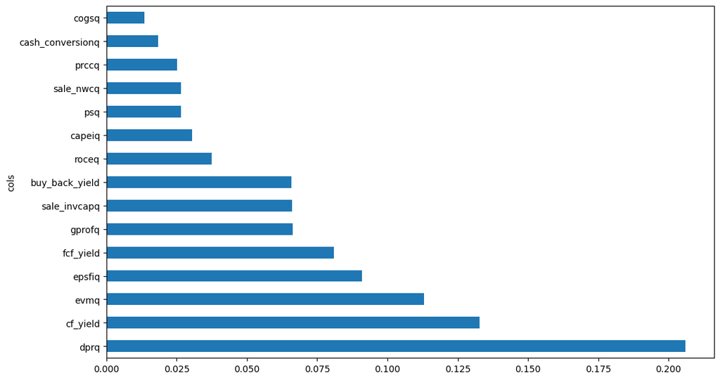

```python
plot_fi(features_simple_t_clf)
```

```python
cols_simple_t_clf = features_simple_t_clf['cols'].values
cols_simple_t_clf
```

```
array(['dprq', 'cf_yield', 'evmq', 'epsfiq', 'fcf_yield', 'gprofq',
       'sale_invcapq', 'buy_back_yield', 'roceq', 'capeiq', 'psq',
       'sale_nwcq', 'prccq', 'cash_conversionq', 'cogsq'], dtype=object)
```

```python
# Features Maximizing Profit - Bagging Classifier

def bagging_feat_importance(m, df):
    feature_importances = []
    for est in m.estimators_:
        fi = est.feature_importances_
        feature_importances.append(fi)
    feature_importances = np.array(feature_importances)

    return pd.DataFrame({'cols':train.columns, 'feat_imp':np.mean(feature_importances,axis=0)}
                       ).sort_values('feat_imp', ascending=False)

def plot_fi(fi): return fi.plot('cols', 'feat_imp', 'barh', figsize=(12,7), legend=False)
```

```python
fi_bg_clf = bagging_feat_importance(bg_clf,train)

features_bg_clf = fi_bg_clf[(fi_bg_clf['feat_imp'] > 0.0)]
features_bg_clf
```

|  | cols | feat_imp |
| --- | --- | --- |
| 108 | dprq | 0.072054 |
| 105 | cf_yield | 0.055049 |
| 95 | evmq | 0.034321 |
| 93 | buy_back_yield | 0.032478 |
| 87 | prccq | 0.026936 |
| ... | ... | ... |
| 96 | pe_op_basicq | 0.000893 |
| 91 | book_value_yield | 0.000843 |
| 22 | epspiq | 0.000790 |
| 42 | opepsq | 0.000745 |
| 26 | ibadjq | 0.000730 |

162 rows × 2 columns

[figure not shown]

```python
plot_fi(features_bg_clf)
```

```python
cols_bg_clf = features_bg_clf['cols'].values
cols_bg_clf
```

```
array(['dprq', 'cf_yield', 'evmq', 'buy_back_yield', 'prccq', 'fcf_yield',
       'ibcomy', 'inv_turnq', 'xsgay', 'dvq', 'sale_invcapq',
       'fcf_csfhdq', 'dltry', 'sale_equityq', 'oiadpq', 'nopiq',
       'quick_ratioq', 'oancfy', 'mibq', 'cstkq', 'rect_turnq', 'gpmq',
       'cash_debtq', 'at_turnq', 'book_value_per_share', 'sale_nwcq',
       'gprofq', 'debt_ebitdaq', 'fcf_ocfq', 'int_totdebtq', 'lt_ppentq',
       'niq', 'txdbq', 'cfmq', 'cdvcy', 'txpdy', 'txditcq', 'invtq',
       'ltq', 'capxy', 'xsgaq', 'de_ratioq', 'prcraq', 'debt_assetsq',
       'dlttq', 'opcfq', 'market_cap', 'chechy', 'ibcomq', 'roaq',
       'xintq', 'cash_conversionq', 'lctq4', 'oancfy_q', 'cogsy', 'ibcq',
       'req', 'dlcq', 'dpcy', 'aftret_equityq', 'opmbdq', 'oepsxy',
       'xrdq', 'pretret_noaq', 'rect_actq', 'debt_atq', 'short_debtq',
       'capeiq', 'intcov_ratioq', 'cheq', 'ocf_lctq', 'pay_turnq', 'apq',
       'intcovq', 'capital_ratioq', 'lagbe4', 'xinty', 'cfo-per-share',
       'lagppent4', 'ptpmq', 'actq', 'piq', 'profit_lctq',
       'debt_capitalq', 'ppentq', 'cogsq', 'curr_debtq', 'ibcy', 'dlcchy',
       'dvy', 'at5', 'invt_actq', 'xoprq', 'cash_ltq', 'lctq', 'oepsxq',
       'pretret_earnatq', 'pe_op_dilq', 'pcfq', 'capxq', 'cshiq',
       'cash_ratioq', 'sic_1311', 'dpq', 'teqq', 'aftret_invcapxq',
       'accrualq', 'lagseq4', 'rectq', 'pe_incq', 'at4', 'dvpspq', 'xrdy',
       'lt_debtq', 'icaptq', 'npmq', 'totdebt_invcapq', 'roeq', 'oibdpq',
       'cshfdq', 'dltisy', 'dltt_beq', 'seqq', 'atq', 'int_debtq', 'txtq',
       'epsx12', 'aftret_eqq', 'dpcq', 'lagicapt4', 'cshprq', 'cshopq',
       'miiq', 'ibq', 'psq', 'txpq', 'bmq', 'beq', 'oepf12',
       'debt_invcapq', 'epspxq', 'optdrq', 'oibdpy', 'equity_invcapq',
       'curr_ratioq', 'be4', 'pe_exiq', 'roceq', 'seq4', 'lagppent_alt4',
       'revtq', 'revty', 'yearly_sales', 'rd_saleq', 'oeps12', 'spiq',
       'pstkq', 'pe_op_basicq', 'book_value_yield', 'epspiq', 'opepsq',
       'ibadjq'], dtype=object)
```

```python
def randomforest_feat_importances(m, df):
    return pd.DataFrame({'cols':df.columns, 'feat_imp': m.feature_importances_}
                       ).sort_values('feat_imp', ascending=False)

def plot_fi(fi): return fi.plot('cols', 'feat_imp', 'barh', figsize=(12,7), legend=False)
```

```python
fi_acc_rf_clf = randomforest_feat_importances(rf_clf,train)
features_acc_rf_clf = fi_acc_rf_clf[(fi_acc_rf_clf['feat_imp'] > 0.00)]
features_acc_rf_clf
```

|  | cols | feat_imp |
| --- | --- | --- |
| 50 | req | 0.092899 |
| 35 | niq | 0.087642 |
| 12 | cstkq | 0.087572 |
| 164 | intcov_ratioq | 0.084716 |
| 76 | oancfy | 0.083783 |
| 38 | oeps12 | 0.079603 |
| 157 | cash_debtq | 0.074190 |
| 40 | oiadpq | 0.068317 |
| 111 | opmadq | 0.058114 |
| 94 | yearly_sales | 0.046536 |
| 133 | aftret_equityq | 0.041886 |
| 18 | epsfi12 | 0.038005 |
| 99 | capeiq | 0.035302 |
| 127 | lagicapt4 | 0.026694 |
| 114 | ibcq | 0.025810 |
| 60 | xintq | 0.023084 |
| 143 | cash_ltq | 0.019529 |
| 32 | ltq | 0.013962 |
| 142 | int_totdebtq | 0.009512 |
| 171 | rect_turnq | 0.002846 |

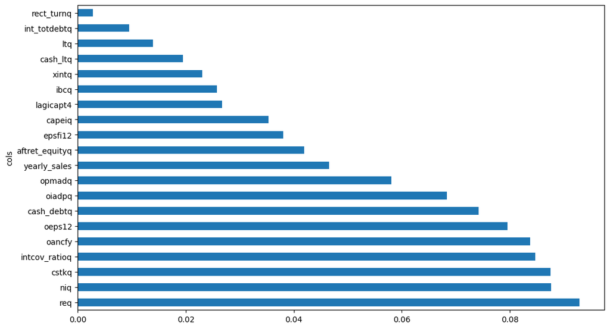

```python
plot_fi(features_acc_rf_clf);
```

```python
train_acc = train[features_acc_rf_clf['cols'].values]
valid_acc = valid[features_acc_rf_clf['cols'].values]

rf_clf.fit(train_acc,y_train)
```

```
RandomForestClassifier(max_depth=12, max_features='log2', min_samples_leaf=2400,
                       n_estimators=10)
```

```python
def profit_importance(m,df,rets):
    profit = []
    for col in df.columns:
        prof = []
        for _ in range(100):
            X = df.copy()
            X[col] = np.random.permutation(df[col].values)
            prediction = m.predict(X)
            prof.append((prediction * rets).sum())
        profit.append(np.mean(prof))
    return profit

def randomforest_profit_importance(m, df,rets):
    return pd.DataFrame({'cols':df.columns, 'pi_imp':profit_importance(m,df,rets)}
                       ).sort_values('pi_imp', ascending=True)
```

```python
pi_rf_clf = randomforest_profit_importance(rf_clf,valid_acc,valid_stock_returns)
pi_rf_clf
```

|  | cols | pi_imp |
| --- | --- | --- |
| 0 | req | -41.687508 |
| 7 | oiadpq | -41.264941 |
| 14 | ibcq | -41.153805 |
| 16 | cash_ltq | -40.070310 |
| 15 | xintq | -39.938512 |
| 13 | lagicapt4 | -39.938512 |
| 11 | epsfi12 | -39.938512 |
| 8 | opmadq | -39.938512 |
| 9 | yearly_sales | -39.938512 |
| 3 | intcov_ratioq | -39.938512 |
| 2 | cstkq | -39.938512 |
| 1 | niq | -39.938512 |
| 6 | cash_debtq | -39.938512 |
| 19 | rect_turnq | -39.903945 |
| 4 | oancfy | -39.725935 |
| 12 | capeiq | -39.615867 |
| 18 | int_totdebtq | -39.613963 |
| 10 | aftret_equityq | -39.445344 |
| 5 | oeps12 | -39.277031 |
| 17 | ltq | -39.198418 |

```
-39.951313000000034
-39.265237000000035
-38.94561100000002
-39.050912000000025
-38.37817600000003
-37.702582000000035
-37.75947100000002
-36.979765000000036
-36.898563000000024
-38.00243200000003
-38.09640500000003
-38.07377100000003
-38.09897700000001
-37.274801000000025
-37.12349600000002
-37.432216000000025
-36.111674000000015
-37.949457000000024
-38.446353000000016
CPU times: user 1min 3s, sys: 1.43 s, total: 1min 4s
Wall time: 1min 5s
```

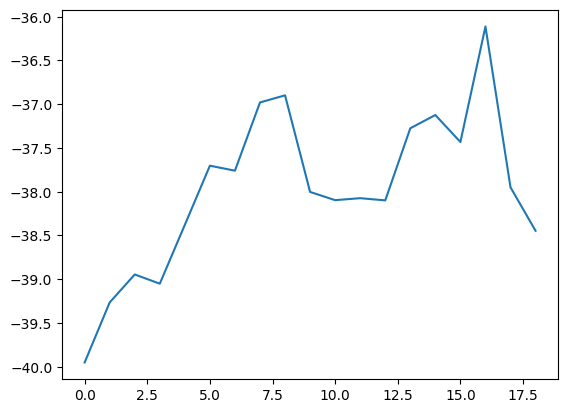

```python
%%time
profits = []
feat=[]

train_copy = train_acc.copy()
validation = valid_acc.copy()

while len(train_copy.columns)>1:

    col_to_drop = pi_rf_clf.iloc[-1]['cols']
    train_copy.drop(col_to_drop,axis=1,inplace=True)
    validation.drop(col_to_drop,axis=1,inplace=True)

    rf_clf.fit(train_copy,y_train)
    pi_rf_clf = randomforest_profit_importance(rf_clf,validation,df_valid['next_period_return'])

    pred_valid = rf_clf.predict(validation)

    print((pred_valid * df_valid['next_period_return']).sum())
    profits.append((pred_valid * df_valid['next_period_return']).sum())
    feat.append(train_copy.columns)

plt.plot(profits);
```

```python
# best profit
n = np.argmax(profits)
profits[n]
```

```
-36.111674000000015
```

```python
# optimal features
optim_feats_rf_clf = feat[n]
optim_feats_rf_clf
```

```
Index(['oiadpq', 'ibcq', 'xintq'], dtype='object')
```

# Q1-d

Back test the performance of the models with the optimal features over the period 2010 – 2018.

```python
# Simple Decision Tree
simple_t_clf.fit(train[cols_simple_t_clf],y_train)
```

```
DecisionTreeClassifier(max_depth=10, min_samples_leaf=700, random_state=123)
```

```python
start_dates = [pd.to_datetime('2007-01-01') + pd.DateOffset(months = 3*i) for i in range(34)]
end_dates = [d + pd.DateOffset(months = 36) for d in start_dates]

training_frames = [data.loc[d:d+pd.DateOffset(months = 36)] for d in start_dates]
test_frames = [data.loc[d + pd.DateOffset(months=6):d+pd.DateOffset(months = 9)] for d in end_dates]
```

```python
training_data = [d.reset_index() for d in training_frames]
test_data = [d.reset_index() for d in test_frames]
training_labels = [d['rel_performance'].values for d in training_frames]
```

```python
scalers = [StandardScaler() for _ in range(len(training_data))]
opt_training_data_simple_t_clf = [pd.DataFrame(scalers[i].fit_transform(training_frames[i][cols_simple_t_clf].values),columns=cols_simple_t_clf) for i in range(len(training_data))]
opt_test_data_simple_t_clf = [pd.DataFrame(scalers[i].transform(test_frames[i][cols_simple_t_clf].values),columns=cols_simple_t_clf) for i in range(len(test_data))]
```

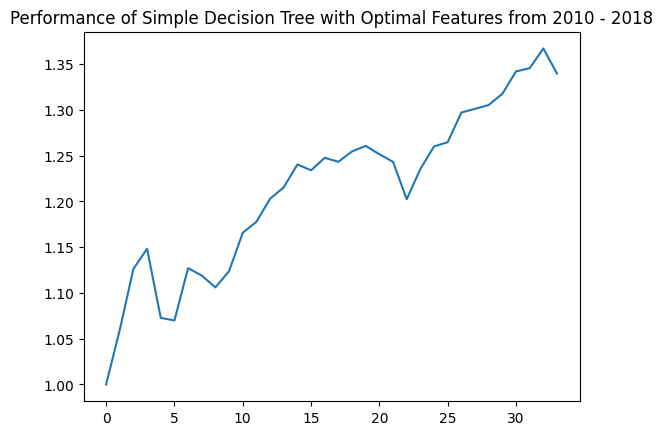

```python
x_simple_t_clf = [1]
ret_simple_t_clf = []

for i in range(len(start_dates)-1):
        simple_t_clf.fit(opt_training_data_simple_t_clf[i],training_labels[i])
        preds = simple_t_clf.predict(opt_test_data_simple_t_clf[i])
        profit_i = (preds*test_frames[i]['next_period_return']).sum()
        ret_simple_t_clf.append(profit_i)
        num_names = len(opt_test_data_simple_t_clf[i])
        x_simple_t_clf.append(x_simple_t_clf[i] + (x_simple_t_clf[i]/num_names)*profit_i)

plt.plot(x_simple_t_clf)
plt.title('Performance of Simple Decision Tree with Optimal Features from 2010 - 2018')
plt.show()
```

```python
# bagging classifier

bg_clf.fit(train[cols_bg_clf],y_train)
```

```
BaggingClassifier(estimator=DecisionTreeClassifier(max_depth=15,
                                                   min_samples_leaf=100),
                  random_state=123)
```

```python
scalers = [StandardScaler() for _ in range(len(training_data))]
opt_training_data_bg_clf = [pd.DataFrame(scalers[i].fit_transform(training_frames[i][cols_bg_clf].values),columns=cols_bg_clf) for i in range(len(training_data))]
opt_test_data_bg_clf = [pd.DataFrame(scalers[i].transform(test_frames[i][cols_bg_clf].values),columns=cols_bg_clf) for i in range(len(test_data))]
```

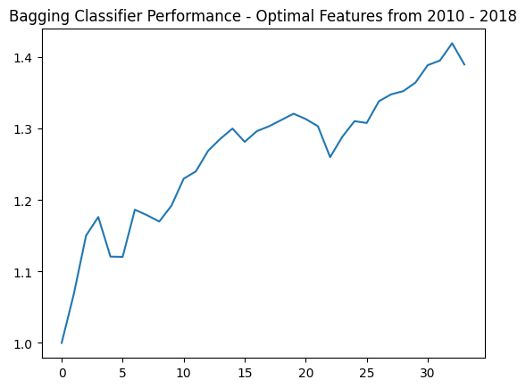

```python
x_bg_clf = [1]
ret_bg_clf = []

for i in range(len(start_dates)-1):
        bg_clf.fit(opt_training_data_bg_clf[i],training_labels[i])
        preds = bg_clf.predict(opt_test_data_bg_clf[i])
        profit_i = (preds*test_frames[i]['next_period_return']).sum()
        ret_bg_clf.append(profit_i)
        num_names = len(opt_test_data_bg_clf[i])
        x_bg_clf.append(x_bg_clf[i] + (x_bg_clf[i]/num_names)*profit_i)

plt.plot(x_bg_clf)
plt.title('Bagging Classifier Performance - Optimal Features from 2010 - 2018')
plt.show()
```

```python
# random forest

rf_clf.fit(train[optim_feats_rf_clf],y_train)
```

```
RandomForestClassifier(max_depth=12, max_features='log2', min_samples_leaf=2400,
                       n_estimators=10)
```

```python
scalers = [StandardScaler() for _ in range(len(training_data))]

opt_training_data_rf_clf = [pd.DataFrame(scalers[i].fit_transform(training_frames[i][optim_feats_rf_clf].values),columns=optim_feats_rf_clf) for i in range(len(training_data))]
opt_test_data_rf_clf = [pd.DataFrame(scalers[i].transform(test_frames[i][optim_feats_rf_clf].values),columns=optim_feats_rf_clf) for i in range(len(test_data))]
```

```python
x_rf_clf = [1]
ret_rf_clf = []

for i in range(len(start_dates)-1):
        rf_clf.fit(opt_training_data_rf_clf[i],training_labels[i])
        preds = rf_clf.predict(opt_test_data_rf_clf[i])
        profit_i = (preds*test_frames[i]['next_period_return']).sum()
        ret_rf_clf.append(profit_i)
        num_names = len(opt_test_data_rf_clf[i])
        x_rf_clf.append(x_rf_clf[i] + (x_rf_clf[i]/num_names)*profit_i)
```

[figure not shown]

```python
plt.plot(x_rf_clf)
plt.title('Random Forest Classifier Performance - Optimal Features from 2010 - 2018')
plt.show()
```

[output not shown]

# Q1-e

Compute Shapley values for the models and find the features with non-zero Shapley values. Train the models on the dataset with these features and back test as above

```python
float_vars_simple_t_clf = [x for x in train[cols_simple_t_clf].columns if data[x].dtype == 'float64']

train_red_norm_simple_t_clf = train.copy()
valid_red_norm_simple_t_clf = valid.copy()
test_red_norm_simple_t_clf = test.copy()

scaler = StandardScaler()
train_red_norm_simple_t_clf[float_vars_simple_t_clf] = scaler.fit_transform((train[cols_simple_t_clf])[float_vars_simple_t_clf])
valid_red_norm_simple_t_clf[float_vars_simple_t_clf] = scaler.transform((valid[cols_simple_t_clf])[float_vars_simple_t_clf])
test_red_norm_simple_t_clf[float_vars_simple_t_clf] = scaler.transform((test[cols_simple_t_clf])[float_vars_simple_t_clf])
```

```python
simple_t_clf.fit(train[cols_simple_t_clf], y_train)
```

```
DecisionTreeClassifier(max_depth=10, min_samples_leaf=700, random_state=123)
```

```python
valid_1_simple_t_clf = valid[cols_simple_t_clf].copy()
valid_1_simple_t_clf['rets'] = df_valid['next_period_return'].values

train_1_simple_t_clf = train[cols_simple_t_clf].copy()
train_1_simple_t_clf['rets'] = df_train['next_period_return'].values
```

```python
# decision tree
def model(features):

    tree_features = features[features.columns[:-1].values]
    pred = simple_t_clf.predict(tree_features)
    ret = pred * features[features.columns[-1]]

    return ret
```

```python
explainer = shap.explainers.Permutation(model,valid_1_simple_t_clf)
shap_values_simple_t_clf = explainer(valid_1_simple_t_clf,max_evals=2000,)
```

```
PermutationExplainer explainer: 1442it [03:55,  5.90it/s]
```

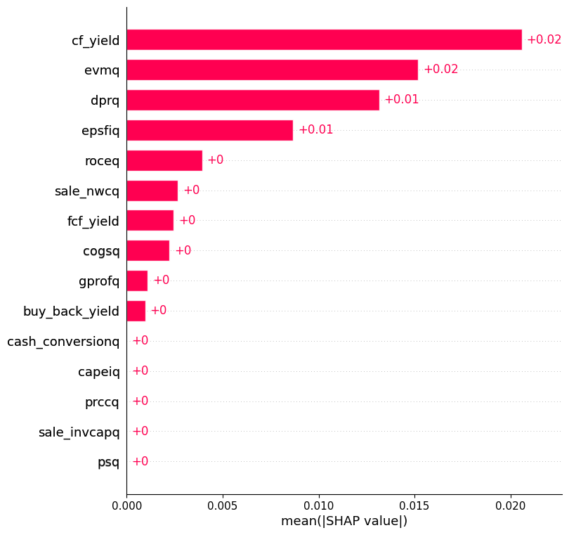

```python
shap.plots.bar(shap_values_simple_t_clf[:,:-1],max_display=30)
```

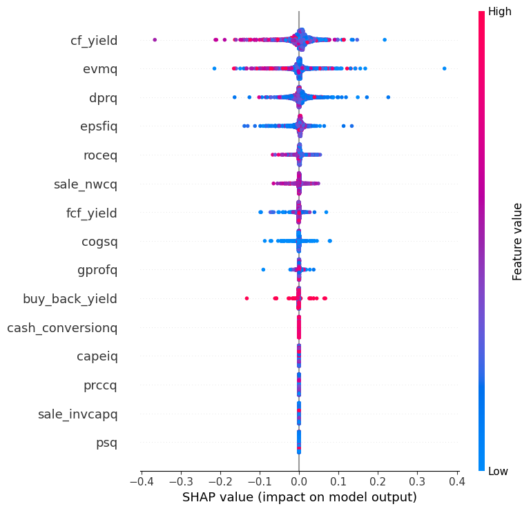

```python
shap.summary_plot(shap_values_simple_t_clf[:,:-1], features=valid_1_simple_t_clf[valid_1_simple_t_clf.columns[:-1]],max_display=30)
```

```python
shap_cols_simple_t_clf = cols_simple_t_clf[np.abs(shap_values_simple_t_clf[:,:-1].values).mean(axis=0)>0.000]

shap_cols_simple_t_clf
```

```
array(['dprq', 'cf_yield', 'evmq', 'epsfiq', 'fcf_yield', 'gprofq',
       'sale_invcapq', 'buy_back_yield', 'roceq', 'capeiq', 'psq',
       'sale_nwcq', 'prccq', 'cash_conversionq', 'cogsq'], dtype=object)
```

```python
simple_t_clf.fit(train[shap_cols_simple_t_clf],y_train)
```

```
DecisionTreeClassifier(max_depth=10, min_samples_leaf=700, random_state=123)
```

```python
scalers = [StandardScaler() for _ in range(len(training_data))]

opt_training_data_simple_t_clf_shap = [pd.DataFrame(scalers[i].fit_transform(training_frames[i][shap_cols_simple_t_clf].values),columns=shap_cols_simple_t_clf) for i in range(len(training_data))]
opt_test_data_simple_t_clf_shap = [pd.DataFrame(scalers[i].transform(test_frames[i][shap_cols_simple_t_clf].values),columns=shap_cols_simple_t_clf) for i in range(len(test_data))]
```

```python
x_simple_t_clf_shap = [1]
ret_simple_t_clf_shap = []

for i in range(len(start_dates)-1):
        simple_t_clf.fit(opt_training_data_simple_t_clf_shap[i],training_labels[i])
        preds = simple_t_clf.predict(opt_test_data_simple_t_clf_shap[i])
        profit_i = (preds*test_frames[i]['next_period_return']).sum()
        ret_simple_t_clf_shap.append(profit_i)
        num_names = len(opt_test_data_simple_t_clf_shap[i])
        x_simple_t_clf_shap.append(x_simple_t_clf_shap[i] + (x_simple_t_clf_shap[i]/num_names)*profit_i)
```

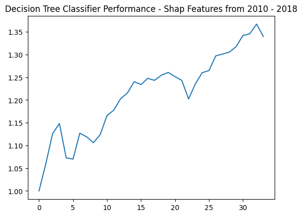

```python
plt.plot(x_simple_t_clf_shap)
plt.title('Decision Tree Classifier Performance - Shap Features from 2010 - 2018')
plt.show()
```

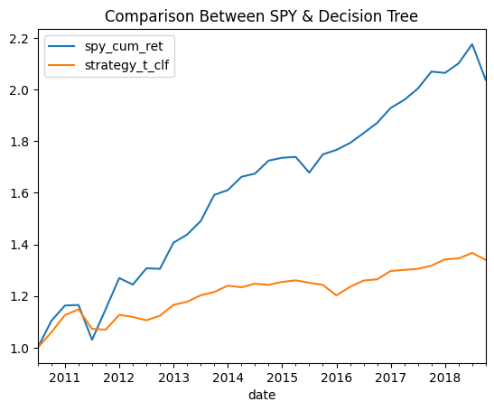

```python
SPY = pd.read_pickle('/Users/yiningqu/Desktop/SPY_cum_ret.pkl')
SPY = SPY.loc['2010-07-01':'2018-12-31']
SPY = SPY.resample('Q').ffill()

SPY_T = SPY.copy()
SPY_T['spy_cum_ret'] = (SPY_T['spy_cum_ret'] - SPY_T['spy_cum_ret'][0]+1)
SPY_T['strategy_t_clf'] = x_simple_t_clf_shap

SPY_T.plot(title='Comparison Between SPY & Decision Tree');
```

```python
SPY_T = SPY_T.resample('Y').ffill()

spy_mean_ret = (SPY_T['spy_cum_ret'] - 1).diff().mean()
spy_std = (SPY_T['spy_cum_ret'] - 1).diff().std()
print('SPY Sharpe Ratio: ',spy_mean_ret/spy_std)
```

```
SPY Sharpe Ratio:  1.1411340547730486
```

```python
strategy_mean_ret_t_clf = (SPY_T['strategy_t_clf'] - 1).diff().mean()
strategy_std_t_clf = (SPY_T['strategy_t_clf'] - 1).diff().std()
strategy_sr_t_clf = strategy_mean_ret_t_clf/strategy_std_t_clf
print('Decision Tree Classifier, Strategy Sharpe Ratio: ',strategy_sr_t_clf)
```

```
Decision Tree Classifier, Strategy Sharpe Ratio:  1.1834764832794356
```

```python
strategy_ret_t_clf = (SPY_T['strategy_t_clf'] - 1).diff().values[1:]
spy_ret_t_clf = (SPY_T['spy_cum_ret'] - 1).diff().values[1:]

beta_t_clf = (np.cov(spy_ret_t_clf,strategy_ret_t_clf)/np.var(spy_ret_t_clf))[1,0]
beta_t_clf
```

```
0.29005447056576183
```

```python
residual_ret_t_clf = strategy_ret_t_clf - beta_t_clf * spy_ret_t_clf
IR_t_clf = np.mean(residual_ret_t_clf)/np.std(residual_ret_t_clf)
print('Decision Tree Classifier, Strategy Information Ratio: ',IR_t_clf)
```

```
Decision Tree Classifier, Strategy Information Ratio:  0.08552852572000658
```

```python
alpha_t_clf = np.mean(residual_ret_t_clf)
alpha_t_clf
print('Decision Tree Classifier, Strategy Quarterly Alpha: ',alpha_t_clf)
```

```
Decision Tree Classifier, Strategy Quarterly Alpha:  0.001175133587688268
```

```python
float_vars_bg_clf = [x for x in train[cols_bg_clf].columns if data[x].dtype == 'float64']

train_red_norm_bg_clf = train.copy()
valid_red_norm_bg_clf = valid.copy()
test_red_norm_bg_clf = test.copy()

scaler = StandardScaler()
train_red_norm_bg_clf[float_vars_bg_clf] = scaler.fit_transform((train[cols_bg_clf])[float_vars_bg_clf])
valid_red_norm_bg_clf[float_vars_bg_clf] = scaler.transform((valid[cols_bg_clf])[float_vars_bg_clf])
test_red_norm_bg_clf[float_vars_bg_clf] = scaler.transform((test[cols_bg_clf])[float_vars_bg_clf])

bg_clf.fit(train[cols_bg_clf],y_train)
```

```
BaggingClassifier(estimator=DecisionTreeClassifier(max_depth=15,
                                                   min_samples_leaf=100),
                  random_state=123)
```

```python
valid_1_bg_cf = valid[cols_bg_clf].copy()
valid_1_bg_cf['rets'] = df_valid['next_period_return'].values

train_1_bg_clf = train[cols_bg_clf].copy()
train_1_bg_clf['rets'] = df_train['next_period_return'].values
```

```python
def model(features):

    tree_features = features[features.columns[:-1].values]
    pred = bg_clf.predict(tree_features)
    ret = pred * features[features.columns[-1]]

    return ret
```

```python
explainer = shap.explainers.Permutation(model,valid_1_bg_cf)
```

```python
shap_values_bg_clf = explainer(valid_1_bg_cf,max_evals=2000,)
```

```
PermutationExplainer explainer: 1442it [54:37,  2.28s/it]
```

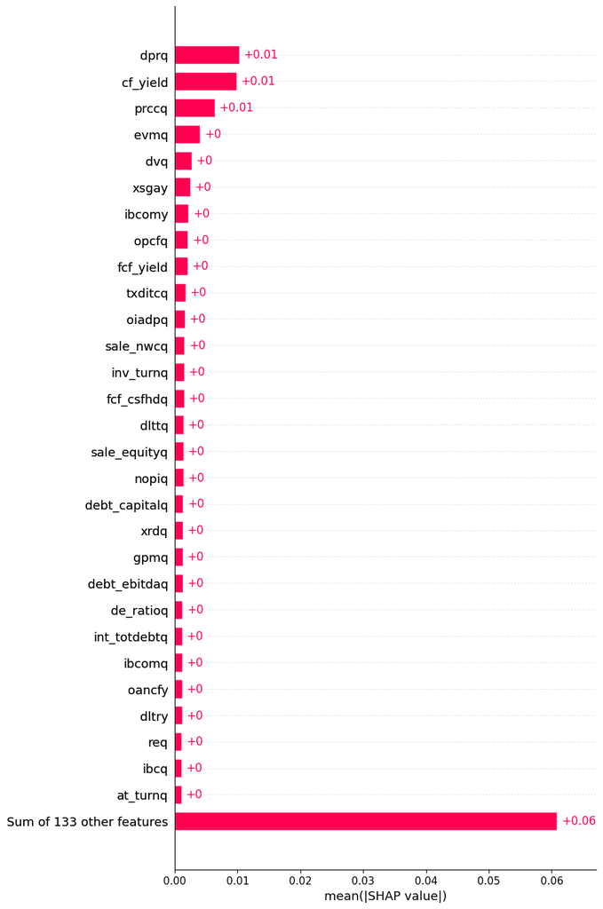

```python
shap.plots.bar(shap_values_bg_clf[:,:-1],max_display=30)
```

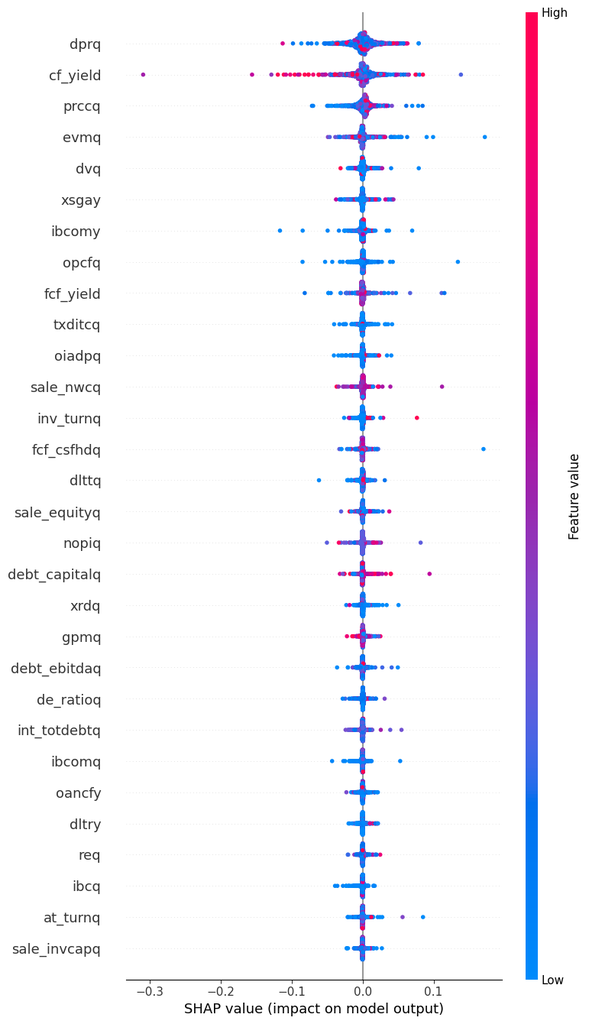

```python
shap.summary_plot(shap_values_bg_clf[:,:-1], features=valid_1_bg_cf[valid_1_bg_cf.columns[:-1]],max_display=30)
```

```python
shap_cols_bg_clf = cols_bg_clf[np.abs(shap_values_bg_clf[:,:-1].values).mean(axis=0)>0.000]
```

```python
shap_cols_bg_clf
```

```
array(['dprq', 'cf_yield', 'evmq', 'buy_back_yield', 'prccq', 'fcf_yield',
       'ibcomy', 'inv_turnq', 'xsgay', 'dvq', 'sale_invcapq',
       'fcf_csfhdq', 'dltry', 'sale_equityq', 'oiadpq', 'nopiq',
       'quick_ratioq', 'oancfy', 'mibq', 'cstkq', 'rect_turnq', 'gpmq',
       'cash_debtq', 'at_turnq', 'book_value_per_share', 'sale_nwcq',
       'gprofq', 'debt_ebitdaq', 'fcf_ocfq', 'int_totdebtq', 'lt_ppentq',
       'niq', 'txdbq', 'cfmq', 'cdvcy', 'txpdy', 'txditcq', 'invtq',
       'ltq', 'capxy', 'xsgaq', 'de_ratioq', 'prcraq', 'debt_assetsq',
       'dlttq', 'opcfq', 'market_cap', 'chechy', 'ibcomq', 'roaq',
       'xintq', 'cash_conversionq', 'lctq4', 'oancfy_q', 'cogsy', 'ibcq',
       'req', 'dlcq', 'dpcy', 'aftret_equityq', 'opmbdq', 'oepsxy',
       'xrdq', 'pretret_noaq', 'rect_actq', 'debt_atq', 'short_debtq',
       'capeiq', 'intcov_ratioq', 'cheq', 'ocf_lctq', 'pay_turnq', 'apq',
       'intcovq', 'capital_ratioq', 'lagbe4', 'xinty', 'cfo-per-share',
       'lagppent4', 'ptpmq', 'actq', 'piq', 'profit_lctq',
       'debt_capitalq', 'ppentq', 'cogsq', 'curr_debtq', 'ibcy', 'dlcchy',
       'dvy', 'at5', 'invt_actq', 'xoprq', 'cash_ltq', 'lctq', 'oepsxq',
       'pretret_earnatq', 'pe_op_dilq', 'pcfq', 'capxq', 'cshiq',
       'cash_ratioq', 'sic_1311', 'dpq', 'teqq', 'aftret_invcapxq',
       'accrualq', 'lagseq4', 'rectq', 'pe_incq', 'at4', 'dvpspq', 'xrdy',
       'lt_debtq', 'icaptq', 'npmq', 'totdebt_invcapq', 'roeq', 'oibdpq',
       'cshfdq', 'dltisy', 'dltt_beq', 'seqq', 'atq', 'int_debtq', 'txtq',
       'epsx12', 'aftret_eqq', 'dpcq', 'lagicapt4', 'cshprq', 'cshopq',
       'miiq', 'ibq', 'psq', 'txpq', 'bmq', 'beq', 'oepf12',
       'debt_invcapq', 'epspxq', 'optdrq', 'oibdpy', 'equity_invcapq',
       'curr_ratioq', 'be4', 'pe_exiq', 'roceq', 'seq4', 'lagppent_alt4',
       'revtq', 'revty', 'yearly_sales', 'rd_saleq', 'oeps12', 'spiq',
       'pstkq', 'pe_op_basicq', 'book_value_yield', 'epspiq', 'opepsq'],
      dtype=object)
```

```python
bg_clf.fit(train[shap_cols_bg_clf],y_train)
```

```
BaggingClassifier(estimator=DecisionTreeClassifier(max_depth=15,
                                                   min_samples_leaf=100),
                  random_state=123)
```

```python
scalers = [StandardScaler() for _ in range(len(training_data))]

opt_training_data_bg_clf_shap = [pd.DataFrame(scalers[i].fit_transform(training_frames[i][shap_cols_bg_clf].values),columns=shap_cols_bg_clf) for i in range(len(training_data))]
opt_test_data_bg_clf_shap = [pd.DataFrame(scalers[i].transform(test_frames[i][shap_cols_bg_clf].values),columns=shap_cols_bg_clf) for i in range(len(test_data))]
```

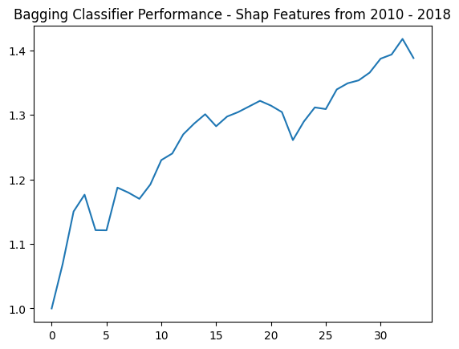

```python
x_bg_clf_shap = [1]
ret_bg_clf_shap = []

for i in range(len(start_dates)-1):
        bg_clf.fit(opt_training_data_bg_clf_shap[i],training_labels[i])
        preds = bg_clf.predict(opt_test_data_bg_clf_shap[i])
        profit_i = (preds*test_frames[i]['next_period_return']).sum()
        ret_bg_clf_shap.append(profit_i)
        num_names = len(opt_test_data_bg_clf_shap[i])
        x_bg_clf_shap.append(x_bg_clf_shap[i] + (x_bg_clf_shap[i]/num_names)*profit_i)

plt.plot(x_bg_clf_shap)
plt.title('Bagging Classifier Performance - Shap Features from 2010 - 2018')
plt.show()
```

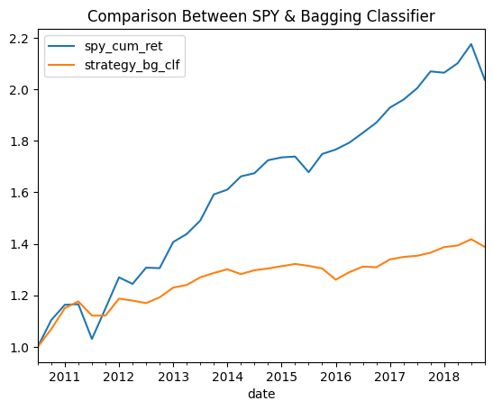

```python
SPY_BG = SPY.copy()
SPY_BG['spy_cum_ret'] = (SPY_BG['spy_cum_ret'] - SPY_BG['spy_cum_ret'][0]+1)
SPY_BG['strategy_bg_clf'] = x_bg_clf_shap

SPY_BG.plot(title='Comparison Between SPY & Bagging Classifier');
```

```python
SPY_BG = SPY_BG.resample('Y').ffill()
spy_mean_ret = (SPY_BG['spy_cum_ret'] - 1).diff().mean()
spy_std = (SPY_BG['spy_cum_ret'] - 1).diff().std()
print('SPY Sharpe Ratio: ',spy_mean_ret/spy_std)
```

```
SPY Sharpe Ratio:  1.1411340547730486
```

```python
strategy_mean_ret_bg_clf = (SPY_BG['strategy_bg_clf'] - 1).diff().mean()
strategy_std_bg_clf = (SPY_BG['strategy_bg_clf'] - 1).diff().std()
strategy_sr_bg_clf = strategy_mean_ret_bg_clf/strategy_std_bg_clf
print('Bagging Classifier, Strategy Sharpe Ratio: ',strategy_sr_bg_clf)
```

```
Bagging Classifier, Strategy Sharpe Ratio:  1.1809822899599394
```

```python
strategy_ret_bg_clf = (SPY_BG['strategy_bg_clf'] - 1).diff().values[1:]
spy_ret_bg_clf = (SPY_BG['spy_cum_ret'] - 1).diff().values[1:]

beta_bg_clf = (np.cov(spy_ret_bg_clf,strategy_ret_bg_clf)/np.var(spy_ret_bg_clf))[1,0]
beta_bg_clf
```

```
0.2605151170020517
```

```python
residual_ret_bg_clf = strategy_ret_bg_clf - beta_bg_clf * spy_ret_bg_clf
IR_bg_clf = np.mean(residual_ret_bg_clf)/np.std(residual_ret_bg_clf)
print('Bagging Classifier, Strategy Information Ratio: ',IR_bg_clf)
```

```
Bagging Classifier, Strategy Information Ratio:  0.4122252391338678
```

```python
alpha_bg_clf = np.mean(residual_ret_bg_clf)
alpha_bg_clf
print('Bagging Classifier, Strategy Quarterly Alpha: ',alpha_bg_clf)
```

```
Bagging Classifier, Strategy Quarterly Alpha:  0.009527365009244637
```

```python
float_vars_rf_clf = [x for x in train[optim_feats_rf_clf].columns if data[x].dtype == 'float64']
len(float_vars_rf_clf)
```

```
3
```

```python
train_red_norm_rf_clf = train.copy()
valid_red_norm_rf_clf = valid.copy()
test_red_norm_rf_clf = test.copy()
```

```python
scaler = StandardScaler()
train_red_norm_rf_clf[float_vars_rf_clf] = scaler.fit_transform((train[optim_feats_rf_clf])[float_vars_rf_clf])
valid_red_norm_rf_clf[float_vars_rf_clf] = scaler.transform((valid[optim_feats_rf_clf])[float_vars_rf_clf])
test_red_norm_rf_clf[float_vars_rf_clf] = scaler.transform((test[optim_feats_rf_clf])[float_vars_rf_clf])
```

```python
rf_clf.fit(train[optim_feats_rf_clf], y_train)
```

```
RandomForestClassifier(max_depth=12, max_features='log2', min_samples_leaf=2400,
                       n_estimators=10)
```

```python
valid_1_rf_clf = valid[optim_feats_rf_clf].copy()
valid_1_rf_clf['rets'] = df_valid['next_period_return'].values

train_1_rf_clf = train[optim_feats_rf_clf].copy()
train_1_rf_clf['rets'] = df_train['next_period_return'].values
```

```python
# random forest
def model(features):

    tree_features = features[features.columns[:-1].values]
    pred = rf_clf.predict(tree_features)
    ret = pred * features[features.columns[-1]]

    return ret

explainer = shap.explainers.Permutation(model,valid_1_rf_clf)
```

```python
shap_values_rf_clf = explainer(valid_1_rf_clf,max_evals=2000,)
```

```
PermutationExplainer explainer: 1442it [15:47,  1.50it/s]
```

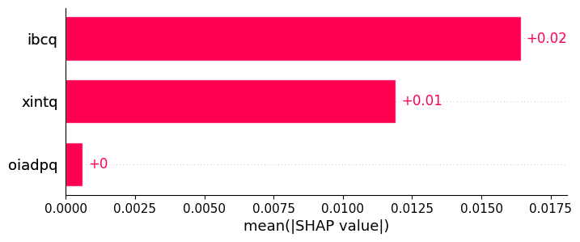

```python
shap.plots.bar(shap_values_rf_clf[:,:-1],max_display=30)
```

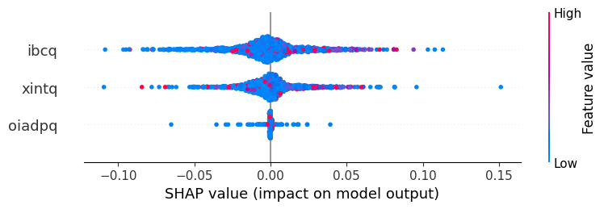

```python
shap.summary_plot(shap_values_rf_clf[:,:-1], features=valid_1_rf_clf[valid_1_rf_clf.columns[:-1]],max_display=30)
```

```python
shap_cols_rf_clf = optim_feats_rf_clf[np.abs(shap_values_rf_clf[:,:-1].values).mean(axis=0)>0.000]

shap_cols_rf_clf
```

```
Index(['oiadpq', 'ibcq', 'xintq'], dtype='object')
```

```python
rf_clf.fit(train[shap_cols_rf_clf],y_train)
```

```
RandomForestClassifier(max_depth=12, max_features='log2', min_samples_leaf=2400,
                       n_estimators=10)
```

```python
scalers = [StandardScaler() for _ in range(len(training_data))]

opt_training_data_rf_clf_shap = [pd.DataFrame(scalers[i].fit_transform(training_frames[i][shap_cols_rf_clf].values),columns=shap_cols_rf_clf) for i in range(len(training_data))]
opt_test_data_rf_clf_shap = [pd.DataFrame(scalers[i].transform(test_frames[i][shap_cols_rf_clf].values),columns=shap_cols_rf_clf) for i in range(len(test_data))]
```

```python
x_rf_clf_shap = [1]
ret_rf_clf_shap = []

for i in range(len(start_dates)-1):
        rf_clf.fit(opt_training_data_rf_clf_shap[i],training_labels[i])
        preds = rf_clf.predict(opt_test_data_rf_clf_shap[i])
        profit_i = (preds*test_frames[i]['next_period_return']).sum()
        ret_rf_clf_shap.append(profit_i)
        num_names = len(opt_test_data_rf_clf_shap[i])
        x_rf_clf_shap.append(x_rf_clf_shap[i] + (x_rf_clf_shap[i]/num_names)*profit_i)
```

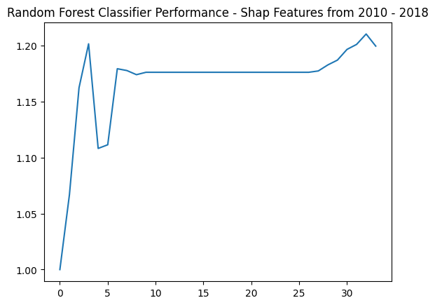

```python
plt.plot(x_rf_clf_shap)
plt.title('Random Forest Classifier Performance - Shap Features from 2010 - 2018')
plt.show()
```

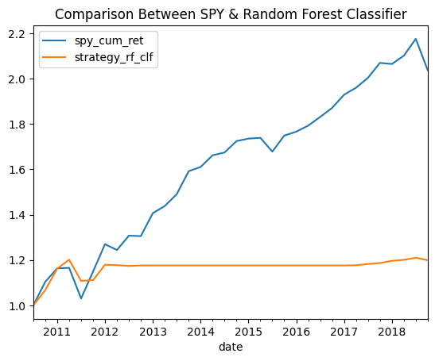

```python
SPY_RF = SPY.copy()
SPY_RF['spy_cum_ret'] = (SPY_RF['spy_cum_ret'] - SPY_RF['spy_cum_ret'][0]+1)
SPY_RF['strategy_rf_clf'] = x_rf_clf_shap
SPY_RF.plot(title='Comparison Between SPY & Random Forest Classifier');
```

```python
SPY_RF = SPY_RF.resample('Y').ffill()

spy_mean_ret = (SPY_RF['spy_cum_ret'] - 1).diff().mean()
spy_std = (SPY_RF['spy_cum_ret'] - 1).diff().std()
print('SPY Sharpe Ratio: ',spy_mean_ret/spy_std)
```

```
SPY Sharpe Ratio:  1.1411340547730486
```

```python
strategy_mean_ret_rf_clf = (SPY_RF['strategy_rf_clf'] - 1).diff().mean()
strategy_std_rf_clf = (SPY_RF['strategy_rf_clf'] - 1).diff().std()
strategy_sr_rf_clf = strategy_mean_ret_rf_clf/strategy_std_rf_clf
print('Random Forest Classifier, Strategy Sharpe Ratio: ',strategy_sr_rf_clf)
```

```
Random Forest Classifier, Strategy Sharpe Ratio:  0.6729232467146984
```

```python
strategy_ret_rf_clf = (SPY_RF['strategy_rf_clf'] - 1).diff().values[1:]
spy_ret_rf_clf = (SPY_RF['spy_cum_ret'] - 1).diff().values[1:]

beta_rf_clf = (np.cov(spy_ret_rf_clf,strategy_ret_rf_clf)/np.var(spy_ret_rf_clf))[1,0]
beta_rf_clf
```

```
-0.02450812254516912
```

```python
residual_ret_rf_clf = strategy_ret_rf_clf - beta_rf_clf * spy_ret_rf_clf
IR_rf_clf = np.mean(residual_ret_rf_clf)/np.std(residual_ret_rf_clf)
print('Random Forest Classifier, Strategy Information Ratio: ',IR_rf_clf)
```

```
Random Forest Classifier, Strategy Information Ratio:  0.8469247008519004
```

```python
alpha_rf_clf = np.mean(residual_ret_rf_clf)
alpha_rf_clf
print('Random Forest Classifier, Strategy Quarterly Alpha: ',alpha_rf_clf)
```

```
Random Forest Classifier, Strategy Quarterly Alpha:  0.019411839461524697
```

# Q2

We make a new definition of profit, instead of using an equal weighted portfolio, we weight the portfolio weights with the probabilities of the labels as follows:

Use the bg_clf.predict_proba on the validation set, this will return an array of the probabilities Probs(-1),Probs(0), Probs(+1) of the labels -1,0,+1 for each stock s so an array of dimension num_stocks x 3. We define the ‘conviction’ of the model for each prediction as

convictions = Probs(+1) – Probs(-1)

and the weights = convictions/∑s' abs(convictions') so ∑sabs(weights) = 1 The profit is then ∑s weights * ‘next_period_return’ Use Optuna and SHAP to find optimal hyperparameters and features, back test and compute Sharp Ratio etc

```python
def objective_4(trial:Trial,train=None,labels=None,val=None,val_labels=None,val_rets=None):

    t_min_samples_leaf = trial.suggest_int('min_samples_leaf',100,1200,step=100)
    t_max_depth = trial.suggest_int('max_depth',5,25,step=5)
    t_n_estimators = trial.suggest_int('n_estimators',5,50,step=5)

    t_clf = DecisionTreeClassifier(min_samples_leaf = t_min_samples_leaf,max_depth=t_max_depth,random_state=123)
    bg_clf = BaggingClassifier(t_clf,n_estimators=t_n_estimators,random_state=123,n_jobs=1)
    bg_clf.fit(train,labels)

    probabilities = bg_clf.predict_proba(val)

    class_order=bg_clf.classes_
    index_minus_one = np.where(class_order == -1)[0][0]
    index_plus_one = np.where(class_order == +1)[0][0]

    conviction_scores = probabilities[:, index_plus_one] - probabilities[:, index_minus_one]

    weights = conviction_scores / np.sum(np.abs(conviction_scores))

    weighted_profit = np.sum(weights * val_rets)

    return weighted_profit
```

```python
study4 = optuna.create_study(direction="maximize")

%%time
study4.optimize(partial(objective_4,train=train,labels=y_train,val=valid,val_labels=y_valid,val_rets=valid_stock_returns.values), n_trials=200,n_jobs=-1)
```

```
[I 2024-02-05 00:59:35,377] A new study created in memory with name: no-name-74837790-0f15-408b-ae5b-6217dd9733fc
UsageError: Line magic function `%%time` not found.
```

```python
%%time
study4.optimize(partial(objective_4,train=train,labels=y_train,val=valid,val_labels=y_valid,val_rets=valid_stock_returns.values), n_trials=200,n_jobs=-1)
```

[output not shown]

[output cut: 174 more lines]

```
CPU times: user 1h 24min 44s, sys: 32.4 s, total: 1h 25min 16s
Wall time: 11min 28s
```

```python
study4.best_params
```

```
{'min_samples_leaf': 100, 'max_depth': 25, 'n_estimators': 10}
```

```python
t_clf_new = DecisionTreeClassifier(**{'min_samples_leaf': study4.best_params['min_samples_leaf'], 'max_depth': study4.best_params['max_depth']})
bg_clf_new = BaggingClassifier(t_clf_new,n_estimators=study4.best_params['n_estimators'],random_state=123)
```

```python
bg_clf_new.fit(train,y_train)
```

```
BaggingClassifier(estimator=DecisionTreeClassifier(max_depth=25,
                                                   min_samples_leaf=100),
                  random_state=123)
```

```python
fi_bg_clf_new = bagging_feat_importance(bg_clf_new,train)
```

```python
features_bg_clf_new = fi_bg_clf_new[(fi_bg_clf_new['feat_imp'] > 0.0)]
features_bg_clf_new
```

|  | cols | feat_imp |
| --- | --- | --- |
| 108 | dprq | 0.071904 |
| 105 | cf_yield | 0.055427 |
| 95 | evmq | 0.034303 |
| 93 | buy_back_yield | 0.032405 |
| 87 | prccq | 0.026907 |
| ... | ... | ... |
| 96 | pe_op_basicq | 0.000893 |
| 91 | book_value_yield | 0.000843 |
| 22 | epspiq | 0.000790 |
| 42 | opepsq | 0.000745 |
| 26 | ibadjq | 0.000730 |

162 rows × 2 columns

[figure not shown]

```python
plot_fi(features_bg_clf_new)
```

```python
cols_bg_clf_new = features_bg_clf_new['cols'].values
cols_bg_clf_new
```

```
array(['dprq', 'cf_yield', 'evmq', 'buy_back_yield', 'prccq', 'fcf_yield',
       'ibcomy', 'inv_turnq', 'xsgay', 'dvq', 'sale_invcapq',
       'fcf_csfhdq', 'dltry', 'sale_equityq', 'oiadpq', 'nopiq',
       'quick_ratioq', 'oancfy', 'mibq', 'cstkq', 'rect_turnq', 'gpmq',
       'cash_debtq', 'at_turnq', 'book_value_per_share', 'gprofq',
       'sale_nwcq', 'debt_ebitdaq', 'int_totdebtq', 'lt_ppentq',
       'fcf_ocfq', 'niq', 'txdbq', 'cfmq', 'cdvcy', 'txpdy', 'invtq',
       'txditcq', 'ltq', 'capxy', 'xsgaq', 'de_ratioq', 'debt_assetsq',
       'dlttq', 'prcraq', 'opcfq', 'market_cap', 'chechy', 'ibcomq',
       'roaq', 'xintq', 'lctq4', 'cash_conversionq', 'oancfy_q', 'cogsy',
       'ibcq', 'req', 'dlcq', 'aftret_equityq', 'dpcy', 'opmbdq', 'xrdq',
       'oepsxy', 'pretret_noaq', 'rect_actq', 'debt_atq', 'short_debtq',
       'capeiq', 'intcov_ratioq', 'cheq', 'ocf_lctq', 'pay_turnq', 'apq',
       'intcovq', 'capital_ratioq', 'lagbe4', 'xinty', 'cfo-per-share',
       'lagppent4', 'ptpmq', 'actq', 'piq', 'profit_lctq',
       'debt_capitalq', 'cogsq', 'ppentq', 'curr_debtq', 'ibcy', 'dlcchy',
       'at5', 'dvy', 'invt_actq', 'xoprq', 'cash_ltq', 'lctq', 'oepsxq',
       'pe_op_dilq', 'pretret_earnatq', 'pcfq', 'capxq', 'cshiq',
       'cash_ratioq', 'sic_1311', 'lagicapt4', 'dpq', 'teqq',
       'aftret_invcapxq', 'accrualq', 'lagseq4', 'rectq', 'pe_incq',
       'at4', 'dvpspq', 'xrdy', 'lt_debtq', 'icaptq', 'npmq',
       'totdebt_invcapq', 'roeq', 'oibdpq', 'cshfdq', 'dltisy',
       'dltt_beq', 'seqq', 'atq', 'int_debtq', 'txtq', 'aftret_eqq',
       'epsx12', 'dpcq', 'cshprq', 'cshopq', 'miiq', 'ibq', 'psq', 'txpq',
       'bmq', 'beq', 'oepf12', 'debt_invcapq', 'epspxq', 'optdrq',
       'oibdpy', 'curr_ratioq', 'equity_invcapq', 'be4', 'pe_exiq',
       'roceq', 'seq4', 'lagppent_alt4', 'revtq', 'revty', 'yearly_sales',
       'rd_saleq', 'oeps12', 'spiq', 'pstkq', 'pe_op_basicq',
       'book_value_yield', 'epspiq', 'opepsq', 'ibadjq'], dtype=object)
```

```python
float_vars_bg_clf_new = [x for x in train[cols_bg_clf_new].columns if data[x].dtype == 'float64']

train_red_norm_bg_clf_new = train.copy()
valid_red_norm_bg_clf_new = valid.copy()
test_red_norm_bg_clf_new = test.copy()

scaler = StandardScaler()
train_red_norm_bg_clf_new[float_vars_bg_clf_new] = scaler.fit_transform((train[cols_bg_clf_new])[float_vars_bg_clf_new])
valid_red_norm_bg_clf_new[float_vars_bg_clf_new] = scaler.transform((valid[cols_bg_clf_new])[float_vars_bg_clf_new])
test_red_norm_bg_clf_new[float_vars_bg_clf_new] = scaler.transform((test[cols_bg_clf_new])[float_vars_bg_clf_new])
```

```python
bg_clf_new.fit(train[cols_bg_clf_new],y_train)
```

```
BaggingClassifier(estimator=DecisionTreeClassifier(max_depth=25,
                                                   min_samples_leaf=100),
                  random_state=123)
```

```python
valid_1_bg_cf_new = valid[cols_bg_clf_new].copy()
valid_1_bg_cf_new['rets'] = df_valid['next_period_return'].values

train_1_bg_clf_new = train[cols_bg_clf_new].copy()
train_1_bg_clf_new['rets'] = df_train['next_period_return'].values
```

```python
def model(features):

    tree_features = features[features.columns[:-1].values]

    probabilities = bg_clf_new.predict_proba(tree_features)

    index_minus_one = np.where(bg_clf_new.classes_ == -1)[0][0]
    index_plus_one = np.where(bg_clf_new.classes_ == +1)[0][0]

    conviction_scores = probabilities[:, index_plus_one] - probabilities[:, index_minus_one]

    weights = conviction_scores / np.sum(np.abs(conviction_scores))

    weighted_returns = weights * features[features.columns[-1]]

    return weighted_returns
```

```python
explainer = shap.explainers.Permutation(model,valid_1_bg_cf_new)
```

```python
shap_values_bg_clf_new = explainer(valid_1_bg_cf_new,max_evals=2000,)
```

```
PermutationExplainer explainer: 1442it [54:07,  2.26s/it]
```

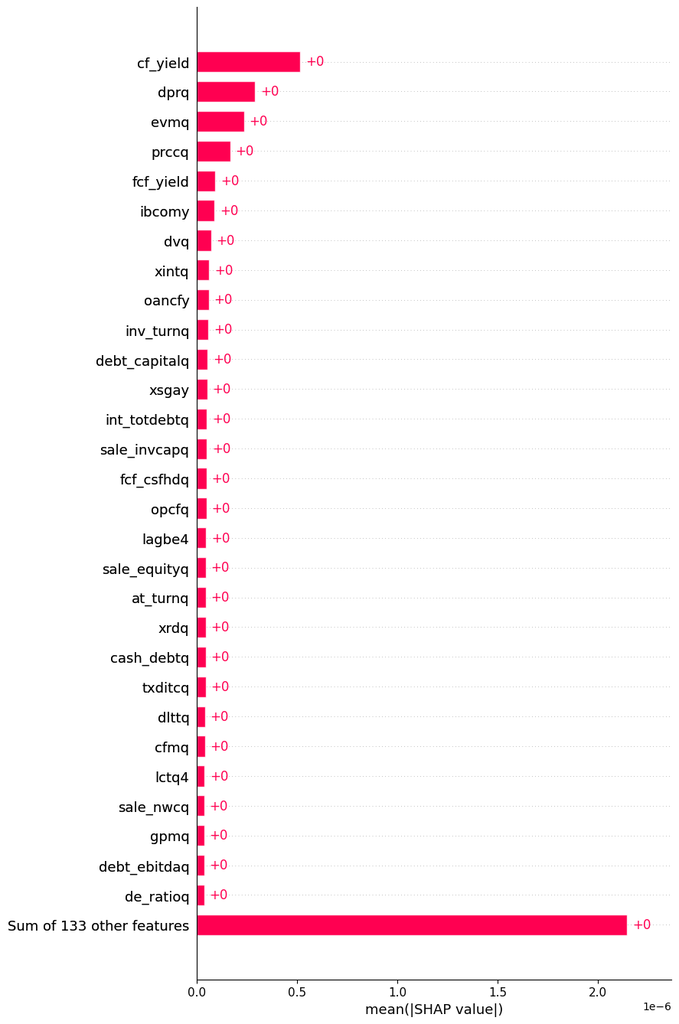

```python
shap.plots.bar(shap_values_bg_clf_new[:,:-1],max_display=30)
```

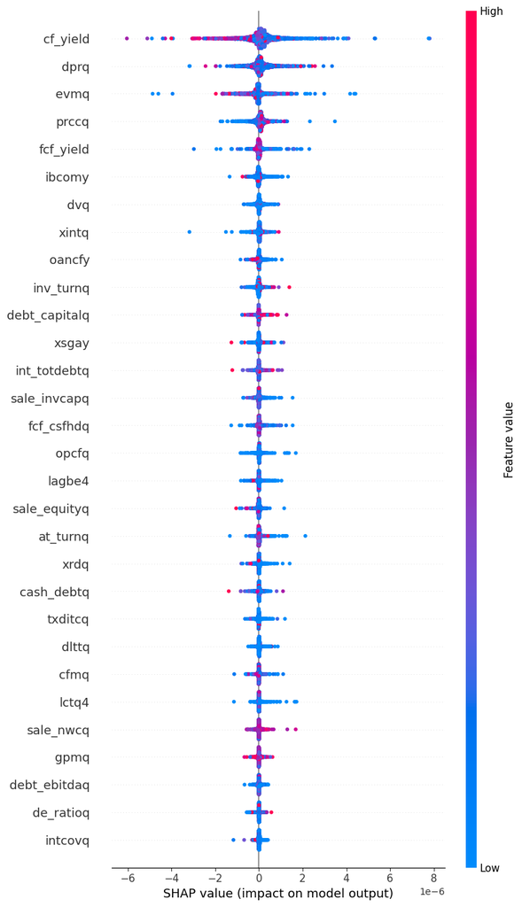

```python
shap.summary_plot(shap_values_bg_clf_new[:,:-1], features=valid_1_bg_cf_new[valid_1_bg_cf_new.columns[:-1]],max_display=30)
```

```python
shap_cols_bg_clf_new = cols_bg_clf_new[np.abs(shap_values_bg_clf_new[:,:-1].values).mean(axis=0)>0.000]

shap_cols_bg_clf_new
```

```
array(['dprq', 'cf_yield', 'evmq', 'buy_back_yield', 'prccq', 'fcf_yield',
       'ibcomy', 'inv_turnq', 'xsgay', 'dvq', 'sale_invcapq',
       'fcf_csfhdq', 'dltry', 'sale_equityq', 'oiadpq', 'nopiq',
       'quick_ratioq', 'oancfy', 'mibq', 'cstkq', 'rect_turnq', 'gpmq',
       'cash_debtq', 'at_turnq', 'book_value_per_share', 'gprofq',
       'sale_nwcq', 'debt_ebitdaq', 'int_totdebtq', 'lt_ppentq',
       'fcf_ocfq', 'niq', 'txdbq', 'cfmq', 'cdvcy', 'txpdy', 'invtq',
       'txditcq', 'ltq', 'capxy', 'xsgaq', 'de_ratioq', 'debt_assetsq',
       'dlttq', 'prcraq', 'opcfq', 'market_cap', 'chechy', 'ibcomq',
       'roaq', 'xintq', 'lctq4', 'cash_conversionq', 'oancfy_q', 'cogsy',
       'ibcq', 'req', 'dlcq', 'aftret_equityq', 'dpcy', 'opmbdq', 'xrdq',
       'oepsxy', 'pretret_noaq', 'rect_actq', 'debt_atq', 'short_debtq',
       'capeiq', 'intcov_ratioq', 'cheq', 'ocf_lctq', 'pay_turnq', 'apq',
       'intcovq', 'capital_ratioq', 'lagbe4', 'xinty', 'cfo-per-share',
       'lagppent4', 'ptpmq', 'actq', 'piq', 'profit_lctq',
       'debt_capitalq', 'cogsq', 'ppentq', 'curr_debtq', 'ibcy', 'dlcchy',
       'at5', 'dvy', 'invt_actq', 'xoprq', 'cash_ltq', 'lctq', 'oepsxq',
       'pe_op_dilq', 'pretret_earnatq', 'pcfq', 'capxq', 'cshiq',
       'cash_ratioq', 'sic_1311', 'lagicapt4', 'dpq', 'teqq',
       'aftret_invcapxq', 'accrualq', 'lagseq4', 'rectq', 'pe_incq',
       'at4', 'dvpspq', 'xrdy', 'lt_debtq', 'icaptq', 'npmq',
       'totdebt_invcapq', 'roeq', 'oibdpq', 'cshfdq', 'dltisy',
       'dltt_beq', 'seqq', 'atq', 'int_debtq', 'txtq', 'aftret_eqq',
       'epsx12', 'dpcq', 'cshprq', 'cshopq', 'miiq', 'ibq', 'psq', 'txpq',
       'bmq', 'beq', 'oepf12', 'debt_invcapq', 'epspxq', 'optdrq',
       'oibdpy', 'curr_ratioq', 'equity_invcapq', 'be4', 'pe_exiq',
       'roceq', 'seq4', 'lagppent_alt4', 'revtq', 'revty', 'yearly_sales',
       'rd_saleq', 'oeps12', 'spiq', 'pstkq', 'pe_op_basicq',
       'book_value_yield', 'epspiq', 'opepsq'], dtype=object)
```

```python
bg_clf_new.fit(train[shap_cols_bg_clf_new],y_train)
```

```
BaggingClassifier(estimator=DecisionTreeClassifier(max_depth=25,
                                                   min_samples_leaf=100),
                  random_state=123)
```

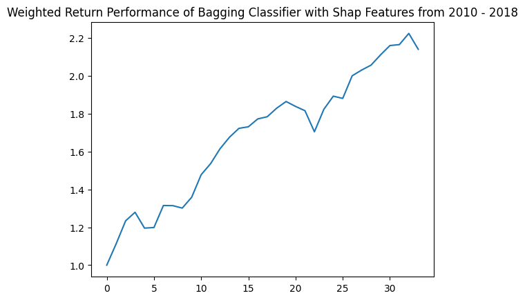

```python
scalers = [StandardScaler() for _ in range(len(training_data))]
opt_training_data_bg_clf_shap_new = [pd.DataFrame(scalers[i].fit_transform(training_frames[i][shap_cols_bg_clf_new].values),columns=shap_cols_bg_clf_new) for i in range(len(training_data))]
opt_test_data_bg_clf_shap_new = [pd.DataFrame(scalers[i].transform(test_frames[i][shap_cols_bg_clf_new].values),columns=shap_cols_bg_clf_new) for i in range(len(test_data))]
x_bg_clf_shap_new = [1]
ret_bg_clf_shap_new = []

for i in range(len(start_dates)-1):
        bg_clf_new.fit(opt_training_data_bg_clf_shap_new[i],training_labels[i])

        probabilities = bg_clf_new.predict_proba(opt_test_data_bg_clf_shap_new[i])

        index_minus_one = np.where(bg_clf_new.classes_ == -1)[0][0]
        index_plus_one = np.where(bg_clf_new.classes_ == +1)[0][0]
        conviction_scores = probabilities[:, index_plus_one] - probabilities[:, index_minus_one]

        weights = conviction_scores / np.sum(np.abs(conviction_scores))

        next_period_returns = test_frames[i]['next_period_return']
        profit_i = np.sum(weights * next_period_returns)

        ret_bg_clf_shap_new.append(profit_i)
        num_names = len(opt_test_data_bg_clf_shap_new[i])

        x_bg_clf_shap_new.append(x_bg_clf_shap_new[i] + profit_i)

plt.plot(x_bg_clf_shap_new)
plt.title('Weighted Return Performance of Bagging Classifier with Shap Features from 2010 - 2018')
plt.show()
```

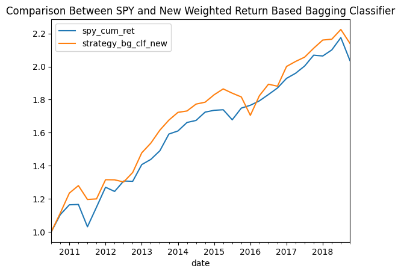

```python
SPY_BG_new = SPY.copy()
SPY_BG_new['spy_cum_ret'] = (SPY_BG_new['spy_cum_ret'] - SPY_BG_new['spy_cum_ret'][0]+1)
SPY_BG_new['strategy_bg_clf_new'] = x_bg_clf_shap_new

SPY_BG_new.plot(title='Comparison Between SPY and New Weighted Return Based Bagging Classifier');
```

```python
SPY_BG_new = SPY_BG_new.resample('Y').ffill()

spy_mean_ret = (SPY_BG_new['spy_cum_ret'] - 1).diff().mean()
spy_std = (SPY_BG_new['spy_cum_ret'] - 1).diff().std()
print('SPY Sharpe Ratio: ',spy_mean_ret/spy_std)
```

```
SPY Sharpe Ratio:  1.1411340547730486
```

```python
strategy_mean_ret_bg_clf_new = (SPY_BG_new['strategy_bg_clf_new'] - 1).diff().mean()
strategy_std_bg_clf_new = (SPY_BG_new['strategy_bg_clf_new'] - 1).diff().std()
strategy_sr_bg_clf_new = strategy_mean_ret_bg_clf_new/strategy_std_bg_clf_new
print('With Bagging Classifier, Weighted Return Strategy Sharpe Ratio: ',strategy_sr_bg_clf_new)
```

```
With Bagging Classifier, Weighted Return Strategy Sharpe Ratio:  1.2660155886117443
```

```python
strategy_ret_bg_clf_new = (SPY_BG_new['strategy_bg_clf_new'] - 1).diff().values[1:]
spy_ret_bg_clf_new = (SPY_BG_new['spy_cum_ret'] - 1).diff().values[1:]

beta_bg_clf_new = (np.cov(spy_ret_bg_clf_new,strategy_ret_bg_clf_new)/np.var(spy_ret_bg_clf_new))[1,0]
beta_bg_clf_new
```

```
1.0549537528446074
```

```python
residual_ret_bg_clf_new = strategy_ret_bg_clf_new - beta_bg_clf_new * spy_ret_bg_clf_new
IR_bg_clf_new = np.mean(residual_ret_bg_clf_new)/np.std(residual_ret_bg_clf_new)
print('With Bagging Classifier, Weighted Return Strategy Information Ratio: ',IR_bg_clf_new)
```

```
With Bagging Classifier, Weighted Return Strategy Information Ratio:  0.14539813513190886
```

```python
alpha_bg_clf_new = np.mean(residual_ret_bg_clf_new)
alpha_bg_clf_new
print('With Bagging Classifier, Weighted Return Strategy Quarterly Alpha: ',alpha_bg_clf_new)
```

```
With Bagging Classifier, Weighted Return Strategy Quarterly Alpha:  0.005393272940715003
```